# Titanic Homework Task

**Created by Dr. James G. Shanahan**

By now we have learned how to solve a problem from end to end using SKLearn, and using pipelines. For example, we learned how to predict house prices in California, how to classify images, etc. In this homework, we push pipelines to the next level as we incorporate feature engineering directly in to the modeling workflow via SKlearn's `Pipeline` class. This will be done in the context of the Titanic Survival classification problem. The following figure gives a quick overview of a possible classification pipeline that you will be building to solve this challenge.

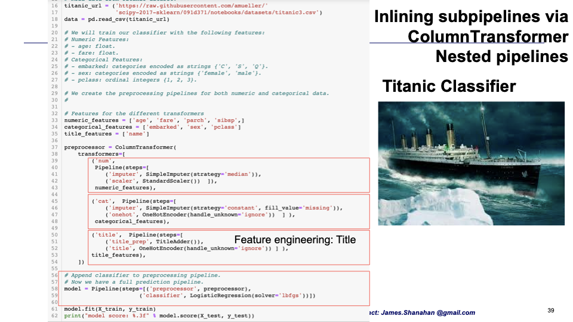

# Submission instructions

1. Before completing this homework,
   - please review this homework's submission form on Canvas available under the "Modules" menu option and
   - briefly review this notebook end to end.
- To get you started we provide a template solution with missing code and prompts. Please complete the missing code, run the experiments and log your results.
- When you're sufficiently happy with your results, please begin the submission process on Canvas. Use the submission form for this homework available under "Modules" menu option. Please note that the submission form is available at the same place where you downloaded the homework from.
- You may wish to reference this quiz while working through the tasks.

Your pipelines will take the following general form:

```
full_pipeline_with_predictor = Pipeline([
        ("preparation", data_pipeline),# combination of numerical, categorical, derived features  subpipelines
        ("logRegression", LogisticRegression())  # classifier estimator you are using
    ])
```

# Data import and EDA

The goal of this section is to get familiar with the data that will be used for training and testing various end to end survivor classifier pipelines. These survivor classifier pipelines will be constructed and tested later in this notebook.

While the main goal of this homework is to predict if a passenger surives the Titanic sinking or not, this section focuses on doing an EDA of the Titanic training dataset before embarking on the pipeline-based modeling.

While doing EDA, we can get insights into the following:

1. What are the profiles of people who survive and not survive?
- Is it true that kids and women are prioritized to survive?
- How does the existence of siblings and parents affect the likelihood to survive?
- Get ideas for feature engineering

## Titanic Dataset

The following graphic from [wikipedia](https://en.wikipedia.org/wiki/Passengers_of_the_RMS_Titanic) presents a breakdown of the survivors versus victoms for each class of passenger and for the crew.

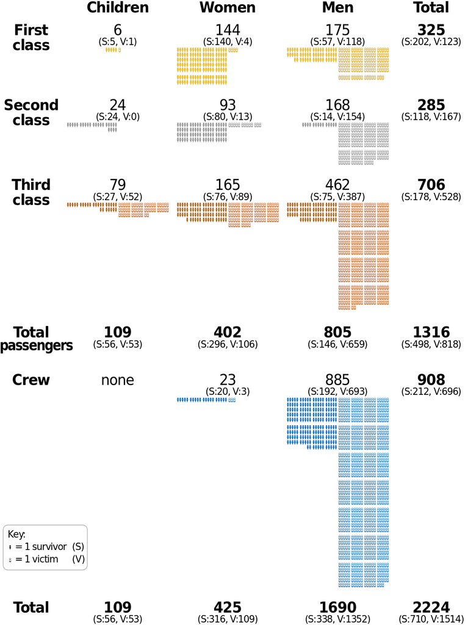

```python
from IPython import display
display.Image("https://upload.wikimedia.org/wikipedia/commons/thumb/6/69/Titanic_casualties.svg/1280px-Titanic_casualties.svg.png", width=500)
```

## Data Dictionary

### Variable descriptions:

The Titanic dataset has the following features for each passenger:

- PassengerId: Id of every passenger.
- Survived: This feature have value 0 and 1. I.e., 0 for not survived and 1 for survived.
- Pclass: There are 3 classes of passengers.
  - Passenger Class: 1 = 1st; 2 = 2nd; 3 = 3rd
- Name: Name of passenger.
- Sex: Gender of passenger.
- Age: Age of passenger.
- SibSp: Indication of the Number of Siblings/Spouses that a passenger has aboard
- Parch: Indication of the Number of Parents/Children that a passenger has aboard.
- Ticket: Ticket no of passenger.
- Fare: Indicating the fare.
- Cabin: The cabin of passenger.
- Embarked: Port of Embarkation
  - (C = Cherbourg; Q = Queenstown; S = Southampton)

### SPECIAL NOTES:

- Pclass is a proxy for socio-economic status (SES)
  - 1st ~ Upper; 2nd ~ Middle; 3rd ~ Lower
- Age is in Years; Fractional if Age less than One (1)
  - If the Age is Estimated, it is in the form xx.5
- With respect to the family relation variables (i.e. sibsp and parch) some relations were ignored. The following are the definitions used for sibsp and parch:
  - Sibling: Brother, Sister, Stepbrother, or Stepsister of Passenger Aboard Titanic
  - Spouse: Husband or Wife of Passenger Aboard Titanic (Mistresses and Fiances Ignored)
  - Parent: Mother or Father of Passenger Aboard Titanic
  - Child: Son, Daughter, Stepson, or Stepdaughter of Passenger Aboard Titanic
- Other family relatives excluded from this study include cousins, nephews/nieces, aunts/uncles, and in-laws. Some children travelled only with a nanny, therefore parch=0 for them. As well, some travelled with very close friends or neighbors in a village, however, the definitions do not support such relations.

## Load the data and split into train, validation and test subsets

```python
#!ls ./datasets/titanic/
```

```python
# imports
import warnings
warnings.simplefilter('ignore')
import seaborn as sns
import matplotlib.pyplot as plt
%matplotlib inline

from sklearn.model_selection import train_test_split  # sklearn.cross_validation in old versions
import re
from time import time
from scipy import stats
import json

import numpy as np
import pandas as pd
# Read data from Titanic dataset.
data = pd.read_csv('datasets/titanic/train.csv')
y = data['Survived']
X = data.drop(['Survived', 'Ticket',  'PassengerId'], axis = 1)  #keep Cabin for EDA

# Split the provided training data into training and validationa and test
X_train, X_test, y_train, y_test = train_test_split(X, y, test_size=0.15, random_state=42)
X_train, X_valid, y_train, y_valid = train_test_split(X_train, y_train, test_size=0.2, random_state=42)
print(f"X train           shape: {X_train.shape}")
print(f"X validation      shape: {X_valid.shape}")
print(f"X test            shape: {X_test.shape}")
X_train.head()
```

```
X train           shape: (605, 9)
X validation      shape: (152, 9)
X test            shape: (134, 9)
```

|  | Pclass | Name | Sex | Age | SibSp | Parch | Fare | Cabin | Embarked |
| --- | --- | --- | --- | --- | --- | --- | --- | --- | --- |
| 513 | 1 | Rothschild, Mrs. Martin (Elizabeth L. Barrett) | female | 54.0 | 1 | 0 | 59.4000 | NaN | C |
| 483 | 3 | Turkula, Mrs. (Hedwig) | female | 63.0 | 0 | 0 | 9.5875 | NaN | S |
| 200 | 3 | Vande Walle, Mr. Nestor Cyriel | male | 28.0 | 0 | 0 | 9.5000 | NaN | S |
| 456 | 1 | Millet, Mr. Francis Davis | male | 65.0 | 0 | 0 | 26.5500 | E38 | S |
| 10 | 3 | Sandstrom, Miss. Marguerite Rut | female | 4.0 | 1 | 1 | 16.7000 | G6 | S |

The `PassengerId` and `Ticket` features are identifiers, unique to each passenger, and as such will not contribute any predictive power to a person's survival probability. So they will be dropped from all future analysis. We will keep `Cabin` in our EDA but will drop it for most of our experiments except one where you will develop a new feature around it as one of your final tasks in this homework.

### For analysis purposes let concatenate X_train and y_train

```python
Xy_train = pd.concat([X_train, y_train], axis=1)
Xy_train.head()
```

|  | Pclass | Name | Sex | Age | SibSp | Parch | Fare | Cabin | Embarked | Survived |
| --- | --- | --- | --- | --- | --- | --- | --- | --- | --- | --- |
| 513 | 1 | Rothschild, Mrs. Martin (Elizabeth L. Barrett) | female | 54.0 | 1 | 0 | 59.4000 | NaN | C | 1 |
| 483 | 3 | Turkula, Mrs. (Hedwig) | female | 63.0 | 0 | 0 | 9.5875 | NaN | S | 1 |
| 200 | 3 | Vande Walle, Mr. Nestor Cyriel | male | 28.0 | 0 | 0 | 9.5000 | NaN | S | 0 |
| 456 | 1 | Millet, Mr. Francis Davis | male | 65.0 | 0 | 0 | 26.5500 | E38 | S | 0 |
| 10 | 3 | Sandstrom, Miss. Marguerite Rut | female | 4.0 | 1 | 1 | 16.7000 | G6 | S | 1 |

```python
#where int64 and float64 are potential numerical features and object  are potential categorical features
#
Xy_train.info()
```

```
<class 'pandas.core.frame.DataFrame'>
Int64Index: 605 entries, 513 to 829
Data columns (total 10 columns):
 #   Column    Non-Null Count  Dtype
---  ------    --------------  -----
 0   Pclass    605 non-null    int64
 1   Name      605 non-null    object
 2   Sex       605 non-null    object
 3   Age       486 non-null    float64
 4   SibSp     605 non-null    int64
 5   Parch     605 non-null    int64
 6   Fare      605 non-null    float64
 7   Cabin     141 non-null    object
 8   Embarked  603 non-null    object
 9   Survived  605 non-null    int64
dtypes: float64(2), int64(4), object(4)
memory usage: 52.0+ KB
```

```python
Xy_train.describe() # examines the numeric features only
```

|  | Pclass | Age | SibSp | Parch | Fare | Survived |
| --- | --- | --- | --- | --- | --- | --- |
| count | 605.000000 | 486.000000 | 605.000000 | 605.000000 | 605.000000 | 605.000000 |
| mean | 2.304132 | 30.000350 | 0.480992 | 0.355372 | 31.954124 | 0.375207 |
| std | 0.829944 | 14.362852 | 1.072713 | 0.764046 | 49.537238 | 0.484577 |
| min | 1.000000 | 0.420000 | 0.000000 | 0.000000 | 0.000000 | 0.000000 |
| 25% | 2.000000 | 21.000000 | 0.000000 | 0.000000 | 7.925000 | 0.000000 |
| 50% | 3.000000 | 28.500000 | 0.000000 | 0.000000 | 14.400000 | 0.000000 |
| 75% | 3.000000 | 38.000000 | 1.000000 | 0.000000 | 30.070800 | 1.000000 |
| max | 3.000000 | 80.000000 | 8.000000 | 5.000000 | 512.329200 | 1.000000 |

Above we can see that 38% out of the training-set survived the Titanic. We can also see that the passenger ages range from 0.4 to 80. On top of that we can already detect some features, that contain missing values, like the ‘Age’ feature (within the numerical features; see below for categorical features).

```python
sum(y_train)/len(y_train) # percentage of people who survived
```

```
0.3752066115702479
```

### Descriptive Statistics for numerical and categorical data including missing values

Use the describe() method on a Pandas DataFrame to get statistics of columns or you could call this method directly on a series. We'll call it on the DataFrame below.

- count shows the number of responses
- unique shows the number of unique categorical values
- top shows the highest-occuring categorical value
- freq shows the frequency/count of the highest-occuring categorical value

```
DataFrame.describe(include = 'all')
```

to get a summary of `all` the columns when the dataframe has mixed column types. The default behavior is to only provide a summary for the numerical columns.

#### data.describe(include='all') and missing values analysis

```python
Xy_train.describe(include='all') # examines the numeric features and categorical features
```

|  | Pclass | Name | Sex | Age | SibSp | Parch | Fare | Cabin | Embarked | Survived |
| --- | --- | --- | --- | --- | --- | --- | --- | --- | --- | --- |
| count | 605.000000 | 605 | 605 | 486.000000 | 605.000000 | 605.000000 | 605.000000 | 141 | 603 | 605.000000 |
| unique | NaN | 605 | 2 | NaN | NaN | NaN | NaN | 109 | 3 | NaN |
| top | NaN | Rothschild, Mrs. Martin (Elizabeth L. Barrett) | male | NaN | NaN | NaN | NaN | G6 | S | NaN |
| freq | NaN | 1 | 402 | NaN | NaN | NaN | NaN | 4 | 448 | NaN |
| mean | 2.304132 | NaN | NaN | 30.000350 | 0.480992 | 0.355372 | 31.954124 | NaN | NaN | 0.375207 |
| std | 0.829944 | NaN | NaN | 14.362852 | 1.072713 | 0.764046 | 49.537238 | NaN | NaN | 0.484577 |
| min | 1.000000 | NaN | NaN | 0.420000 | 0.000000 | 0.000000 | 0.000000 | NaN | NaN | 0.000000 |
| 25% | 2.000000 | NaN | NaN | 21.000000 | 0.000000 | 0.000000 | 7.925000 | NaN | NaN | 0.000000 |
| 50% | 3.000000 | NaN | NaN | 28.500000 | 0.000000 | 0.000000 | 14.400000 | NaN | NaN | 0.000000 |
| 75% | 3.000000 | NaN | NaN | 38.000000 | 1.000000 | 0.000000 | 30.070800 | NaN | NaN | 1.000000 |
| max | 3.000000 | NaN | NaN | 80.000000 | 8.000000 | 5.000000 | 512.329200 | NaN | NaN | 1.000000 |

```python
#  Fill code to find which column number had the most missing values
#print(f"{......} has the most missing values")

print(f"{np.argmax(Xy_train.isna().sum().sort_values())} has the most missing values")
```

```
9 has the most missing values
```

```python
Xy_train.shape
```

```
(605, 10)
```

```python
Xy_train.dtypes.value_counts()
```

```
int64      4
object     4
float64    2
dtype: int64
```

### determine the categorical and numerical features

```python
numerical_ix = Xy_train.select_dtypes(include=['int64', 'float64']).columns
categorical_ix = Xy_train.select_dtypes(include=['object', 'bool']).columns
print(f"numerical   features: {list(numerical_ix)}")
print(f"categorical features: {list(categorical_ix)}")
```

```
numerical   features: ['Pclass', 'Age', 'SibSp', 'Parch', 'Fare', 'Survived']
categorical features: ['Name', 'Sex', 'Cabin', 'Embarked']
```

## Correlation Observations

### Review: Correlation between a continous input variable and a discrete output variable

Measuring correlation between a continous input variable and a discrete output variable is possible the target variable has only two levels. In that binary case, you can use point [biserial correlation](https://en.wikipedia.org/wiki/Point-biserial_correlation_coefficient). For some great backgound see:

- binary case: see https://en.wikipedia.org/wiki/Point-biserial_correlation_coefficient
- n-ary case: see
  - https://stats.stackexchange.com/questions/119835/correlation-between-a-nominal-iv-and-a-continuous-dv-variable/124618#124618

#### Case 1: When an Variable Only Has Two Values

**Point Biserial Correlation** If a categorical variable only has two values (i.e. true/false), then we can convert it into a numeric datatype (0 and 1). Since it becomes a numeric variable, we can find out the correlation using the dataframe.corr() function.

Let's create a dataframe which will consist of two columns: `Employee Type` (EmpType) and `Salary`.

Purposely, we will assign more salary to `EmpType1`. This way we will get some correlation between EmpType and Salary.

Create a dataframe with the following properties:

Mean (average) salary of EmpType1 is 60 with a standard deviation of five.

Mean (average) salary of EmpType2 is 50 with a standard deviation of five.

```python
import pandas as pd
import numpy as np
num1=np.random.normal(loc=60,scale=5,size=100)
df1=pd.DataFrame(num1,columns=['Salary'])
df1['Type']='EmpType1'
num2=np.random.normal(loc=50,scale=5,size=100)
df2=pd.DataFrame(num2,columns=['Salary'])
df2['Type']='EmpType2'
df=pd.concat([df1,df2],axis=0)
# Since Categorical variable 'Type' has only 2 values we will convert it into numeric (0 and 1) datatype.
df['TypeInt']=(df['Type']=='EmpType1').astype(int)
df.corr()
```

|  | Salary | TypeInt |
| --- | --- | --- |
| Salary | 1.000000 | 0.716471 |
| TypeInt | 0.716471 | 1.000000 |

#### Case 2: When an Independent Variable Has more Values : THIS IS NOT CORRECT!

```python
from sklearn.datasets import load_iris
import numpy as np
import pandas as pd
from IPython.display import display
# load the data
iris = load_iris()
all_iris = pd.DataFrame.from_records(data=np.c_[iris.data, iris.target], columns=iris.feature_names+["class"])

display(all_iris)
all_iris.corr()  #not correct for 3-class target (output) categorial variable
```

|  | sepal length (cm) | sepal width (cm) | petal length (cm) | petal width (cm) | class |
| --- | --- | --- | --- | --- | --- |
| 0 | 5.1 | 3.5 | 1.4 | 0.2 | 0.0 |
| 1 | 4.9 | 3.0 | 1.4 | 0.2 | 0.0 |
| 2 | 4.7 | 3.2 | 1.3 | 0.2 | 0.0 |
| 3 | 4.6 | 3.1 | 1.5 | 0.2 | 0.0 |
| 4 | 5.0 | 3.6 | 1.4 | 0.2 | 0.0 |
| ... | ... | ... | ... | ... | ... |
| 145 | 6.7 | 3.0 | 5.2 | 2.3 | 2.0 |
| 146 | 6.3 | 2.5 | 5.0 | 1.9 | 2.0 |
| 147 | 6.5 | 3.0 | 5.2 | 2.0 | 2.0 |
| 148 | 6.2 | 3.4 | 5.4 | 2.3 | 2.0 |
| 149 | 5.9 | 3.0 | 5.1 | 1.8 | 2.0 |

150 rows × 5 columns

|  | sepal length (cm) | sepal width (cm) | petal length (cm) | petal width (cm) | class |
| --- | --- | --- | --- | --- | --- |
| sepal length (cm) | 1.000000 | -0.117570 | 0.871754 | 0.817941 | 0.782561 |
| sepal width (cm) | -0.117570 | 1.000000 | -0.428440 | -0.366126 | -0.426658 |
| petal length (cm) | 0.871754 | -0.428440 | 1.000000 | 0.962865 | 0.949035 |
| petal width (cm) | 0.817941 | -0.366126 | 0.962865 | 1.000000 | 0.956547 |
| class | 0.782561 | -0.426658 | 0.949035 | 0.956547 | 1.000000 |

### Correlation of Titanic numeric input variables with the Survived variable

```python
# Show the correlation of the Survived column with the other numeric features
corr_matrix = Xy_train.corr()
display(corr_matrix)
corr_matrix["abs_Survived"] = np.abs(corr_matrix["Survived"])
display(corr_matrix)
corr_matrix.sort_values("abs_Survived", ascending=False, inplace=True)
display(corr_matrix)
corr_matrix["Survived"]
```

|  | Pclass | Age | SibSp | Parch | Fare | Survived |
| --- | --- | --- | --- | --- | --- | --- |
| Pclass | 1.000000 | -0.347893 | 0.056715 | 0.009430 | -0.552116 | -0.313027 |
| Age | -0.347893 | 1.000000 | -0.253111 | -0.158142 | 0.086163 | -0.082327 |
| SibSp | 0.056715 | -0.253111 | 1.000000 | 0.393073 | 0.176231 | -0.016515 |
| Parch | 0.009430 | -0.158142 | 0.393073 | 1.000000 | 0.222604 | 0.108801 |
| Fare | -0.552116 | 0.086163 | 0.176231 | 0.222604 | 1.000000 | 0.257249 |
| Survived | -0.313027 | -0.082327 | -0.016515 | 0.108801 | 0.257249 | 1.000000 |

|  | Pclass | Age | SibSp | Parch | Fare | Survived | abs_Survived |
| --- | --- | --- | --- | --- | --- | --- | --- |
| Pclass | 1.000000 | -0.347893 | 0.056715 | 0.009430 | -0.552116 | -0.313027 | 0.313027 |
| Age | -0.347893 | 1.000000 | -0.253111 | -0.158142 | 0.086163 | -0.082327 | 0.082327 |
| SibSp | 0.056715 | -0.253111 | 1.000000 | 0.393073 | 0.176231 | -0.016515 | 0.016515 |
| Parch | 0.009430 | -0.158142 | 0.393073 | 1.000000 | 0.222604 | 0.108801 | 0.108801 |
| Fare | -0.552116 | 0.086163 | 0.176231 | 0.222604 | 1.000000 | 0.257249 | 0.257249 |
| Survived | -0.313027 | -0.082327 | -0.016515 | 0.108801 | 0.257249 | 1.000000 | 1.000000 |

|  | Pclass | Age | SibSp | Parch | Fare | Survived | abs_Survived |
| --- | --- | --- | --- | --- | --- | --- | --- |
| Survived | -0.313027 | -0.082327 | -0.016515 | 0.108801 | 0.257249 | 1.000000 | 1.000000 |
| Pclass | 1.000000 | -0.347893 | 0.056715 | 0.009430 | -0.552116 | -0.313027 | 0.313027 |
| Fare | -0.552116 | 0.086163 | 0.176231 | 0.222604 | 1.000000 | 0.257249 | 0.257249 |
| Parch | 0.009430 | -0.158142 | 0.393073 | 1.000000 | 0.222604 | 0.108801 | 0.108801 |
| Age | -0.347893 | 1.000000 | -0.253111 | -0.158142 | 0.086163 | -0.082327 | 0.082327 |
| SibSp | 0.056715 | -0.253111 | 1.000000 | 0.393073 | 0.176231 | -0.016515 | 0.016515 |

```
Survived    1.000000
Pclass     -0.313027
Fare        0.257249
Parch       0.108801
Age        -0.082327
SibSp      -0.016515
Name: Survived, dtype: float64
```

- *Pclass* and *Fare* are the most highly correlated with survivorship. A higher fare indicates a higher chance of surviving; a lower class (where "first" class is better than "third") indicates a higher chance of survinging.
- *Sex* and *Embarked* do not appear in the correlation list, because they are not numeric values. We can one-hot encode this column and re-examine later.

## pair plot the data (scatterplot and historgrams by target variable hue)

A very useful seaborn plot is the pairplot, which shows the bivariate relation between each pair of features From the pairplot, we'll see that the Titanic passengers survival class is not separated by any pair of features.

```
Titanic Dataset: 0 for not survived and 1 for survived.
```

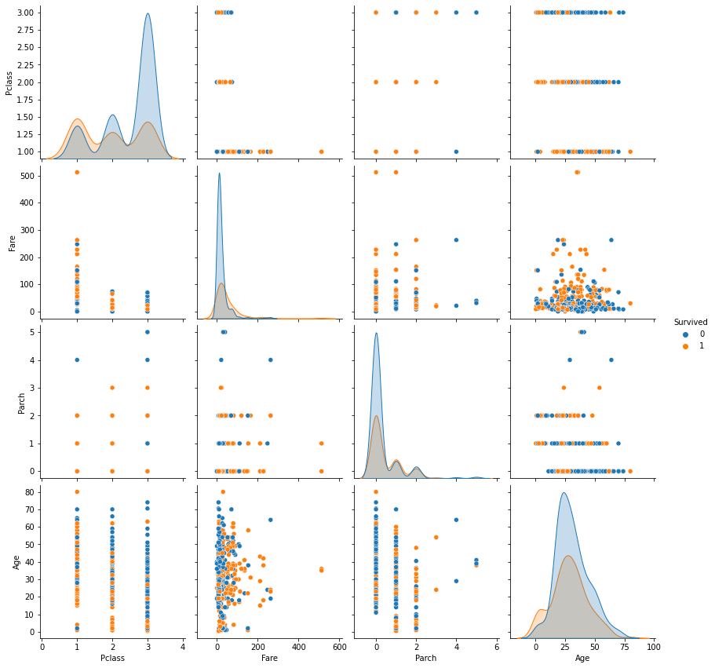

```python
import numpy as np # linear algebra
import pandas as pd # data processing, CSV file I/O (e.g. pd.read_csv)
import seaborn as sns #Statistical Data Visualization
import matplotlib.pyplot as plt
%matplotlib inline
#pairplot
# Top four correlated inputs with survived
#df['Survived'] = df['Survived'].astype(str)
attributes = ["Pclass", "Fare",  "Parch", "Age"]
print("Titanic Dataset: 0 for not survived and 1 for survived.")
sns.pairplot(data = Xy_train, hue="Survived", vars = attributes, height=3)
```

## Evaluate categorical features with respect to Survived

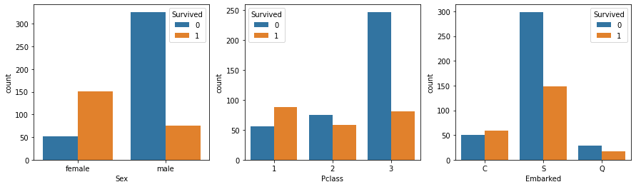

```python
cat_vars = ['Sex', 'Pclass', 'Embarked']
plt.figure(figsize=(15,4))
for idx, cat in enumerate(cat_vars):
    plt.subplot(1, 3, idx+1)
    sns.countplot(Xy_train[cat], hue=Xy_train['Survived'])
```

## Is it true that kids and women are prioritized to survive?

```python
sum(X_train['Sex']=="female")
```

```
203
```

```python
sum(X_train['Age']<3)
```

```
18
```

```python
sum((X_train['Age']<3) | (X_train['Sex'] == "female"))
```

```
212
```

```python
kids_or_woman = y_train[(X_train['Age']<3) | (X_train['Sex'] == "female")]  #NOTE: union versus intersection
kids_or_woman.value_counts()
```

```
1    156
0     56
Name: Survived, dtype: int64
```

This result indicates that kids or women are more likely to survive than die.

## How does the existence of siblings and parents affect the likelihood to survive?

```python
sum(X_train['SibSp']+ X_train['Parch']<1)
```

```
369
```

```python
sum(y_train[X_train['SibSp']+ X_train['Parch']>=1])
```

```
120
```

```python
no_sibling_or_parent  = y_train[X_train['SibSp']+ X_train['Parch']<1]
has_sibling_or_parent = y_train[X_train['SibSp']+ X_train['Parch']>=1]
print("Traveling solo")
print(no_sibling_or_parent.value_counts())
print('____________________')
print("Traveling with siblings/parent")
print(has_sibling_or_parent.value_counts())
print(f"Traveling solo survival rate        : {100*np.round(107/(262+107), 2)}%")
print(f"Traveling with someone survival rate: {100*np.round(120/(120+116), 2)}%")
```

```
Traveling solo
0    262
1    107
Name: Survived, dtype: int64
____________________
Traveling with siblings/parent
1    120
0    116
Name: Survived, dtype: int64
Traveling solo survival rate        : 28.999999999999996%
Traveling with someone survival rate: 51.0%
```

These results indicate the likelihood to survive is more if a person is traveling with somebody else. Traveling solo did not lead to a good survival rate.

[output not shown]

# Build data preprocessing pipelines

In this part of the homework the focus is on constructing the pipeline. Since the data has both numerical and categorical features, it is required to create at least two pipelines (one for each type of data at least) because they require different transformations. After finishing that, the two pipelines should be unified to produce one full pipeline that transforms all the data together.

## A simple yet complex pipeline

```
data_pipeline

ColumnTransformer(n_jobs=None, remainder='drop', sparse_threshold=0.3,
                  transformer_weights=None,
                  transformers=[('pipeline-1',
                                 Pipeline(memory=None,
                                          steps=[('simpleimputer',
                                                  SimpleImputer(add_indicator=False,
                                                                copy=True,
                                                                fill_value=None,
                                                                missing_values=nan,
                                                                strategy='mean',
                                                                verbose=0)),
                                                 ('standardscaler',
                                                  StandardScaler(copy=True,
                                                                 with_mean=True,
                                                                 with_std=True))],
                                          ve...
                                          steps=[('simpleimputer',
                                                  SimpleImputer(add_indicator=False,
                                                                copy=True,
                                                                fill_value=None,
                                                                missing_values=nan,
                                                                strategy='most_frequent',
                                                                verbose=0)),
                                                 ('onehotencoder',
                                                  OneHotEncoder(categorical_features=None,
                                                                categories=None,
                                                                drop=None,
                                                                dtype=<class 'numpy.float64'>,
                                                                handle_unknown='error',
                                                                n_values=None,
                                                                sparse=True))],
                                          verbose=False),
                                 ['Sex', 'Embarked'])],
                  verbose=False)
```

### Accessing the column names of the transformed data

Get access to the names of the columns takes a little bit of effort especially for one-hot-encoded features. The following example shows how to acces the OHE dummy or category variables via

```
get_feature_names(categorical_features).
```

for the `categorical_features`.

```
X_train_transformed = data_pipeline.fit_transform(X_train)
column_names = numerical_features  + list(data_pipeline.transformers_[1][1].named_steps["onehotencoder"].get_feature_names(categorical_features))
display(pd.DataFrame(X_train_transformed,  columns=column_names).head())
```

[figure not shown]

### An inline pipeline! Super compact!!

```python
from sklearn.pipeline import Pipeline, FeatureUnion, make_pipeline
from sklearn.compose import ColumnTransformer
import numpy as np
import pandas as pd
from sklearn.preprocessing import StandardScaler, OneHotEncoder
from sklearn.compose import ColumnTransformer, make_column_transformer
from sklearn.model_selection import train_test_split  # sklearn.cross_validation in old versions
from sklearn.preprocessing import StandardScaler, OneHotEncoder
from sklearn.linear_model import LogisticRegression
from sklearn.impute import SimpleImputer
from time import time


data = pd.read_csv('datasets/titanic/train.csv')
y = data['Survived']
X = data.drop(['Survived', 'Ticket', 'Cabin', 'PassengerId'], axis = 1) #drop some features with questionable value
# drop some categorical features for now
# we will do some feature engineering around this feature later
X = X.drop(['Name'], axis = 1)

# Split the provided training data into training and validationa and test
X_train, X_test, y_train, y_test = train_test_split(X, y, test_size=0.15, random_state=42)
X_train, X_valid, y_train, y_valid = train_test_split(X_train, y_train, test_size=0.2, random_state=42)
print(f"X train           shape: {X_train.shape}")
print(f"X validation      shape: {X_valid.shape}")
print(f"X test            shape: {X_test.shape}")

# determine categorical and numerical features
numerical_features = list(X.select_dtypes(include=['int64', 'float64']).columns)
categorical_features = list(X.select_dtypes(include=['object', 'bool']).columns)
print(f"numerical_features are  : {numerical_features}")
print(f"categorical_features are: {categorical_features}")
data_pipeline = make_column_transformer( #Level 2
    (make_pipeline(SimpleImputer(), StandardScaler()),      numerical_features), #level 3
    (make_pipeline(SimpleImputer(strategy='most_frequent'),
                   OneHotEncoder(handle_unknown='ignore')), categorical_features)
  )
X_train_transformed = data_pipeline.fit_transform(X_train)
print(type(X_train_transformed))
column_names = numerical_features  + list(data_pipeline.transformers_[1][1].named_steps["onehotencoder"].get_feature_names(categorical_features))
display(pd.DataFrame(X_train_transformed,  columns=column_names).head())
number_of_inputs = X_train_transformed.shape[1]

# Now we can combine this preprocessing step based on the ColumnTransformer with a
# classifier in a Pipeline to predict whether passengers of the Titanic survived or not:
clf_pipe = make_pipeline( #level 1
    data_pipeline,
    LogisticRegression())

# Time and score test predictions
start = time()
clf_pipe.fit(X_train, y_train)
train_time = np.round(time() - start, 4)

trainAcc  = clf_pipe.score(X_train, y_train)
validAcc  = clf_pipe.score(X_valid, y_valid)
start = time()
testAcc  = clf_pipe.score(X_test, y_test)
test_time = np.round(time() - start, 4)

#del experimentLog
try: experimentLog
except : experimentLog = pd.DataFrame(columns=["Pipeline", "Dataset", "TrainAcc", "ValidAcc", "TestAcc",
                                               "Train Time(s)",  "Test Time(s)", "Description",])
experimentLog.loc[len(experimentLog)] =[f"Baseline 1 LogReg with {number_of_inputs} inputs", "Titanic classes",
                                        f"{trainAcc*100:8.2f}%", f"{validAcc*100:8.2f}%", f"{testAcc*100:8.2f}%",
                                        train_time, test_time,
                                        "Baseline 1 LogReg pipeline with Cat+Num features"]

experimentLog
```

```
X train           shape: (605, 7)
X validation      shape: (152, 7)
X test            shape: (134, 7)
numerical_features are  : ['Pclass', 'Age', 'SibSp', 'Parch', 'Fare']
categorical_features are: ['Sex', 'Embarked']
<class 'numpy.ndarray'>
```

|  | Pclass | Age | SibSp | Parch | Fare | Sex_female | Sex_male | Embarked_C | Embarked_Q | Embarked_S |
| --- | --- | --- | --- | --- | --- | --- | --- | --- | --- | --- |
| 0 | -1.572650 | 1.866255 | 0.484228 | -0.465503 | 0.554504 | 1.0 | 0.0 | 1.0 | 0.0 | 0.0 |
| 1 | 0.839145 | 2.566111 | -0.448759 | -0.465503 | -0.451885 | 1.0 | 0.0 | 0.0 | 0.0 | 1.0 |
| 2 | 0.839145 | -0.155551 | -0.448759 | -0.465503 | -0.453653 | 0.0 | 1.0 | 0.0 | 0.0 | 1.0 |
| 3 | -1.572650 | 2.721635 | -0.448759 | -0.465503 | -0.109182 | 0.0 | 1.0 | 0.0 | 0.0 | 1.0 |
| 4 | 0.839145 | -2.021833 | 0.484228 | 0.844401 | -0.308187 | 1.0 | 0.0 | 0.0 | 0.0 | 1.0 |

|  | Pipeline | Dataset | TrainAcc | ValidAcc | TestAcc | Train Time(s) | Test Time(s) | Description |
| --- | --- | --- | --- | --- | --- | --- | --- | --- |
| 0 | Baseline 1 LogReg with 10 inputs | Titanic classes | 79.01% | 82.24% | 80.60% | 0.0244 | 0.0065 | Baseline 1 LogReg pipeline with Cat+Num features |

## Baseline classifier pipeline

```python
from sklearn.pipeline import Pipeline, FeatureUnion, make_pipeline
from sklearn.compose import ColumnTransformer
from sklearn.datasets import load_iris
import numpy as np
import pandas as pd
from sklearn.model_selection import train_test_split  # sklearn.cross_validation in old versions
from sklearn.preprocessing import StandardScaler, OneHotEncoder
from sklearn.linear_model import LogisticRegression
from sklearn.impute import SimpleImputer


data = pd.read_csv('datasets/titanic/train.csv')
y = data['Survived']
X = data.drop(['Survived', 'Ticket', 'Cabin', 'PassengerId'], axis = 1) #drop some features with questionable value

# Split the provided training data into training and validationa and test
X_train, X_test, y_train, y_test = train_test_split(X, y, test_size=0.15, random_state=42)
X_train, X_valid, y_train, y_valid = train_test_split(X_train, y_train, test_size=0.2, random_state=42)
print(f"X train           shape: {X_train.shape}")
print(f"X validation      shape: {X_valid.shape}")
print(f"X test            shape: {X_test.shape}")

# Identify the numeric features we wish to consider.
numerical_features = [
    'Age',
    'Parch',
    'SibSp',
    'Fare'
]

# Create a pipeline for the numeric features.
# Use StandardScaler() to standardize the data
# Missing values will be imputed using the feature median.
#==================================================#
#               Your code starts here              #
#==================================================#

# TODO - change the following code
num_pipeline =Pipeline([('std',StandardScaler()),('imputer', SimpleImputer(strategy='median'))])

#==================================================#
#               Your code ends here                #
#               Please don't add code below here   #
#==================================================#


# Identify the categorical features we wish to consider.
categorical_features = [
    "Embarked",
    "Sex",
    "Pclass"
]
# Identify the range of expected values for the categorical features.
cat_values = [
    ['S','C','Q'],     # Embarked
    ['female','male'], # Sex
    [1,2,3] # Pclass
]

# Create a pipelne for the categorical features.
# Entries with missing values or values that don't exist in the range
# defined above will be one hot encoded as zeroes.
cat_pipeline = Pipeline([
        ('imputer', SimpleImputer(strategy='most_frequent')),
        ('ohe', OneHotEncoder(sparse=False, handle_unknown="ignore"))
    ])

#==================================================#
#               Your code starts here              #
#==================================================#
# merge the scaled numeric and categorical features.
# drop all unused features
data_pipeline = ColumnTransformer([
      ( "num_pipeline",num_pipeline, numerical_features),("cat_pipeline",cat_pipeline, categorical_features)],remainder='drop',
        n_jobs=5)


# TODO - change the following code
# data_pipeline = ColumnTransformer()

#==================================================#
#               Your code ends here                #
#               Please don't add code below here   #
#==================================================#

X_train_transformed = data_pipeline.fit_transform(X_train)
column_names = numerical_features  + \
               list(data_pipeline.transformers_[1][1].named_steps["ohe"].get_feature_names(categorical_features))
display(pd.DataFrame(X_train_transformed,  columns=column_names).head())
number_of_inputs = X_train_transformed.shape[1]
# Now we can combine this preprocessing step based on the ColumnTransformer with a
# classifier in a Pipeline to predict whether passengers of the Titanic survived or not:
clf_pipe = make_pipeline(
    data_pipeline,
    LogisticRegression())
# Time and score test predictions
start = time()
clf_pipe.fit(X_train, y_train)
train_time = np.round(time() - start, 4)

trainAcc  = clf_pipe.score(X_train, y_train)
validAcc  = clf_pipe.score(X_valid, y_valid)
start = time()
testAcc  = clf_pipe.score(X_test, y_test)
test_time = np.round(time() - start, 4)

#del experimentLog
try: experimentLog
except : experimentLog = pd.DataFrame(columns=["Pipeline", "Dataset", "TrainAcc", "ValidAcc", "TestAcc",
                                               "Train Time(s)",  "Test Time(s)", "Description",])
experimentLog.loc[len(experimentLog)] =[f"Baseline 2 LogReg with {number_of_inputs} inputs", "Titanic classes",
                                        f"{trainAcc*100:8.2f}%", f"{validAcc*100:8.2f}%", f"{testAcc*100:8.2f}%",
                                        train_time, test_time,
                                        "Baseline 2 LogReg pipeline with Cat+Num features"]

experimentLog
```

```
X train           shape: (605, 8)
X validation      shape: (152, 8)
X test            shape: (134, 8)
```

|  | Age | Parch | SibSp | Fare | Embarked_C | Embarked_Q | Embarked_S | Sex_female | Sex_male | Pclass_1 | Pclass_2 | Pclass_3 |
| --- | --- | --- | --- | --- | --- | --- | --- | --- | --- | --- | --- | --- |
| 0 | 1.672675 | -0.465503 | 0.484228 | 0.554504 | 1.0 | 0.0 | 0.0 | 1.0 | 0.0 | 1.0 | 0.0 | 0.0 |
| 1 | 2.299937 | -0.465503 | -0.448759 | -0.451885 | 0.0 | 0.0 | 1.0 | 1.0 | 0.0 | 0.0 | 0.0 | 1.0 |
| 2 | -0.139416 | -0.465503 | -0.448759 | -0.453653 | 0.0 | 0.0 | 1.0 | 0.0 | 1.0 | 0.0 | 0.0 | 1.0 |
| 3 | 2.439328 | -0.465503 | -0.448759 | -0.109182 | 0.0 | 0.0 | 1.0 | 0.0 | 1.0 | 1.0 | 0.0 | 0.0 |
| 4 | -1.812115 | 0.844401 | 0.484228 | -0.308187 | 0.0 | 0.0 | 1.0 | 1.0 | 0.0 | 0.0 | 0.0 | 1.0 |

|  | Pipeline | Dataset | TrainAcc | ValidAcc | TestAcc | Train Time(s) | Test Time(s) | Description |
| --- | --- | --- | --- | --- | --- | --- | --- | --- |
| 0 | Baseline 1 LogReg with 10 inputs | Titanic classes | 79.01% | 82.24% | 80.60% | 0.0244 | 0.0065 | Baseline 1 LogReg pipeline with Cat+Num features |
| 1 | Baseline 2 LogReg with 12 inputs | Titanic classes | 79.34% | 82.24% | 79.10% | 0.7500 | 0.0101 | Baseline 2 LogReg pipeline with Cat+Num features |
| 2 | Baseline 2 LogReg with 12 inputs | Titanic classes | 79.34% | 82.24% | 79.10% | 0.0285 | 0.0121 | Baseline 2 LogReg pipeline with Cat+Num features |

### Why is there a difference in the two baseline pipelines (Hint `Pclass`)

The classifier pipelines in section 4.1 lead to pipelines with different parameters and coefficients (see the test accuracies for both pipelines is different).

Why is this? Please explain in your own words.

# Feature engineering part 1 of 3: title feature

Feature engineering is so important to how your modeling pipeline performs, that even a simple pipeline with great features can outperform a complicated one with poor ones. In fact, feature engineering has been described as easily the most important factor in determining the success or failure of your predictive pipeline. Feature engineering, sometimes, really boils down to the human element in machine learning. How much you understand the data, with your human intuition, creativity, and domain expertise, can make the difference.

When conducting an end to end Machine Learning project, after exploring and preprocessing the data it is essential to think of `feature engineering`. It consists of creating new feature(s) based on the features that already exist in the dataset (or that can be merged in from an external/third-party dataset). These features can then be used in during training the pipeline.

## Develop a new feature based on the title from each passengers name

### Explore the distribution of titles

```python
from sklearn.model_selection import train_test_split  # sklearn.cross_validation in old versions

data = pd.read_csv('datasets/titanic/train.csv')
y = data['Survived']
X = data.drop(['Survived', 'Ticket', 'Cabin', 'PassengerId'], axis = 1) #drop some features with questionable value

# Split the provided training data into training and validationa and test
X_train, X_test, y_train, y_test = train_test_split(X, y, test_size=0.15, random_state=42)
X_train, X_valid, y_train, y_valid = train_test_split(X_train, y_train, test_size=0.2, random_state=42)

X_train['Name'][0:10].str.extract(' ([A-Z][a-z]+)\.').values.reshape(-1)
```

```
array(['Mrs', 'Mrs', 'Mr', 'Mr', 'Miss', 'Mr', 'Mr', 'Mr', 'Master', 'Mr'],
      dtype=object)
```

```python
titles_df = pd.DataFrame({"name":X_train['Name'],
              "Title": X_train['Name'].str.extract(' ([A-Z][a-z]+)\.').values.reshape(-1) } )
titles_df.head(10)
```

|  | name | Title |
| --- | --- | --- |
| 513 | Rothschild, Mrs. Martin (Elizabeth L. Barrett) | Mrs |
| 483 | Turkula, Mrs. (Hedwig) | Mrs |
| 200 | Vande Walle, Mr. Nestor Cyriel | Mr |
| 456 | Millet, Mr. Francis Davis | Mr |
| 10 | Sandstrom, Miss. Marguerite Rut | Miss |
| 762 | Barah, Mr. Hanna Assi | Mr |
| 557 | Robbins, Mr. Victor | Mr |
| 692 | Lam, Mr. Ali | Mr |
| 831 | Richards, Master. George Sibley | Master |
| 187 | Romaine, Mr. Charles Hallace ("Mr C Rolmane") | Mr |

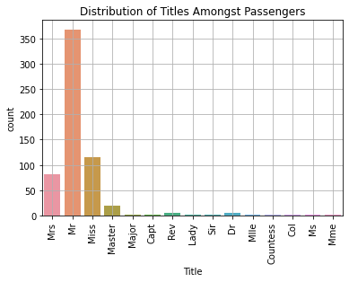

```python
sns.countplot(x='Title', data=titles_df)
plt.title('Distribution of Titles Amongst Passengers')
plt.xticks(rotation=90);
plt.grid()
```

### Consolidate special and miscellaneous titles

Most titles fall into one of four categories (`Mr`, `Mrs`, `Miss`, `Master`). All other titles can either be:

- assigned naturally to one of the top four (e.g., `Ms` can grouped with `Miss` with any loss of information)
- or be grouped as `other`.

```
Mr        369
Miss      119
Mrs        82
Master     19
Other      16
Name: Title, dtype: int64
```

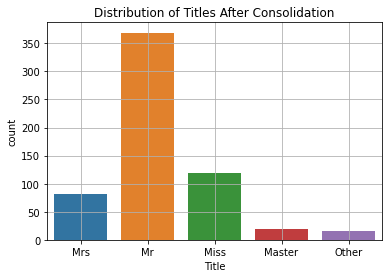

```python
titles_df['Title'] = titles_df['Title'].replace({'Mlle':'Miss', 'Mme':'Mrs', 'Ms':'Miss'})
titles_df['Title'] = titles_df['Title'].replace(['Don', 'Dona', 'Rev', 'Dr','Major', 'Lady', 'Sir',
                                       'Col', 'Capt', 'Countess', 'Jonkheer'],'Other')
sns.countplot(x='Title', data=titles_df);
plt.title('Distribution of Titles After Consolidation')
plt.grid()
titles_df['Title'].value_counts()
```

## Create a transformer to perfom this new feature transformation in a pipeline

```python
from sklearn.base import BaseEstimator, TransformerMixin
from sklearn.pipeline import make_pipeline
import re
from sklearn.pipeline import Pipeline, FeatureUnion, make_pipeline
from sklearn.compose import ColumnTransformer
from sklearn.datasets import load_iris
import numpy as np
import pandas as pd
from sklearn.model_selection import train_test_split  # sklearn.cross_validation in old versions
from sklearn.impute import SimpleImputer


data = pd.read_csv('datasets/titanic/train.csv')
y = data['Survived']
X = data.drop(['Survived', 'Ticket', 'Cabin', 'PassengerId'], axis = 1) #drop some features with questionable value

# Split the provided training data into training and validationa and test
X_train, X_test, y_train, y_test = train_test_split(X, y, test_size=0.15, random_state=42)
X_train, X_valid, y_train, y_valid = train_test_split(X_train, y_train, test_size=0.2, random_state=42)
print(f"X train           shape: {X_train.shape}")
print(f"X validation      shape: {X_valid.shape}")
print(f"X test            shape: {X_test.shape}")


class TitleAdder(BaseEstimator, TransformerMixin):
    def __init__(self, features=None): # no *args or **kargs
        self.features = features
    def fit(self, X, y=None):
        return self  # nothing else to do
    def transform(self, X):
        df = pd.DataFrame(X.copy(), columns=self.features)  # select a subset of columns in X based on self.features
        #display(df)
        print(f"self.features: {self.features}")
        #from IPython.core.debugger import Pdb as pdb;    pdb().set_trace() #breakpoint; dont forget to quit

        # use .str API to access re package in vectorized form
        df['Title'] = df[self.features[0]].str.extract(' ([A-Z][a-z]+)\.')
        # using the apply() method
        df['Title'] = df[self.features[0]].apply(lambda x: re.search(' ([A-Z][a-z]+)\.', x).group(1))

        # Apply the necessary transformations to obtain the 5 title categories
        # (Mr, Mrs, Miss, Master, Other) like it was done in section 5.1.2
        df['Title'] = df['Title'].replace({'Mlle':'Miss', 'Mme':'Mrs', 'Ms':'Miss'})
        df['Title'] = df['Title'].replace(['Don', 'Dona', 'Rev', 'Dr','Major', 'Lady', 'Sir',
                                           'Col', 'Capt', 'Countess', 'Jonkheer'],'Other')
        #drop text features as we need to switch from a generic dateframe to a Numpy Array with the title column
        df.drop(self.features, axis=1, inplace=True)
        return df

test_pipeline = make_pipeline(TitleAdder(['Name']))
display(test_pipeline.fit_transform(X_train).head())


# test_driver_title_simple_TWO_step_pipeline(X_train):
test_pipeline = make_pipeline(TitleAdder(['Name']),
                              OneHotEncoder(handle_unknown='ignore'))
X_ts_sparse = test_pipeline.fit_transform(X_train)
ohe_col_names = list(test_pipeline.named_steps["onehotencoder"].categories_[0])
#from IPython.core.debugger import Pdb as pdb;    pdb().set_trace() #breakpoint; dont forget to quit
pd.DataFrame(np.c_[X_train["Name"],X_ts_sparse.toarray()], columns=['Name'] + ohe_col_names)
```

```
X train           shape: (605, 8)
X validation      shape: (152, 8)
X test            shape: (134, 8)
self.features: ['Name']
```

|  | Title |
| --- | --- |
| 513 | Mrs |
| 483 | Mrs |
| 200 | Mr |
| 456 | Mr |
| 10 | Miss |

```
self.features: ['Name']
```

|  | Name | Master | Miss | Mr | Mrs | Other |
| --- | --- | --- | --- | --- | --- | --- |
| 0 | Rothschild, Mrs. Martin (Elizabeth L. Barrett) | 0.0 | 0.0 | 0.0 | 1.0 | 0.0 |
| 1 | Turkula, Mrs. (Hedwig) | 0.0 | 0.0 | 0.0 | 1.0 | 0.0 |
| 2 | Vande Walle, Mr. Nestor Cyriel | 0.0 | 0.0 | 1.0 | 0.0 | 0.0 |
| 3 | Millet, Mr. Francis Davis | 0.0 | 0.0 | 1.0 | 0.0 | 0.0 |
| 4 | Sandstrom, Miss. Marguerite Rut | 0.0 | 1.0 | 0.0 | 0.0 | 0.0 |
| ... | ... | ... | ... | ... | ... | ... |
| 600 | Peter, Mrs. Catherine (Catherine Rizk) | 0.0 | 0.0 | 0.0 | 1.0 | 0.0 |
| 601 | Johnson, Mr. William Cahoone Jr | 0.0 | 0.0 | 1.0 | 0.0 | 0.0 |
| 602 | Jerwan, Mrs. Amin S (Marie Marthe Thuillard) | 0.0 | 0.0 | 0.0 | 1.0 | 0.0 |
| 603 | Dorking, Mr. Edward Arthur | 0.0 | 0.0 | 1.0 | 0.0 | 0.0 |
| 604 | Stone, Mrs. George Nelson (Martha Evelyn) | 0.0 | 0.0 | 0.0 | 1.0 | 0.0 |

605 rows × 6 columns

## Classifier pipeline with title feature

```python
from sklearn.pipeline import Pipeline, FeatureUnion, make_pipeline
from sklearn.compose import ColumnTransformer
from sklearn.datasets import load_iris
import numpy as np
import pandas as pd
from sklearn.model_selection import train_test_split  # sklearn.cross_validation in old versions
from sklearn.preprocessing import StandardScaler, OneHotEncoder
from sklearn.linear_model import LogisticRegression
from sklearn.impute import SimpleImputer


data = pd.read_csv('datasets/titanic/train.csv')
y = data['Survived']
X = data.drop(['Survived', 'Ticket', 'Cabin', 'PassengerId'], axis = 1) #drop some features with questionable value

# Split the provided training data into training and validationa and test
X_train, X_test, y_train, y_test = train_test_split(X, y, test_size=0.15, random_state=42)
X_train, X_valid, y_train, y_valid = train_test_split(X_train, y_train, test_size=0.2, random_state=42)
print(f"X train           shape: {X_train.shape}")
print(f"X validation      shape: {X_valid.shape}")
print(f"X test            shape: {X_test.shape}")

# Identify the numeric features we wish to consider.
numerical_features = [
    'Age',
    'Parch',
    'SibSp',
    'Fare'
]

num_pipeline = Pipeline([
        ('imputer', SimpleImputer(strategy="median")),
        ('std_scaler', StandardScaler()),
    ])

# Identify the categorical features we wish to consider.
categorical_features = [
    "Embarked",
    "Sex",
    "Pclass"
]
# Identify the range of expected values for the categorical features.
cat_values = [
    ['S','C','Q'],     # Embarked
    ['female','male'], # Sex
    [1,2,3] # Pclass
]

cat_pipeline = Pipeline([
        ('imputer', SimpleImputer(strategy='most_frequent')),
        ('ohe', OneHotEncoder(sparse=False, handle_unknown="ignore"))
    ])


# Complete the code for the entire data pipeline
# with numerical feature, categorical feature ,and the title feature.
# Use OneHotEncoder(handle_unknown='ignore')) to OHE
#  Drop all remaining features

#==================================================#
#               Your code starts here              #
#==================================================#
name_feature = ["Name"]
data_pipeline = ColumnTransformer( transformers= [("num_pipeline", num_pipeline, numerical_features),
    ("cat_pipeline", cat_pipeline, categorical_features),
    ("title_pipeline",  make_pipeline(TitleAdder(name_feature), OneHotEncoder(handle_unknown='ignore')), name_feature)],
                                  remainder = 'drop', n_jobs=5)



#==================================================#
#               Your code ends here                #
#               Please don't add code below here   #
#==================================================#


X_train_transformed = data_pipeline.fit_transform(X_train)
column_names = numerical_features  + \
               list(data_pipeline.transformers_[1][1].named_steps["ohe"].get_feature_names(categorical_features)) +\
               list(data_pipeline.transformers_[2][1].named_steps["onehotencoder"].get_feature_names(name_feature))

display(pd.DataFrame(X_train_transformed,  columns=column_names).head())
number_of_inputs = X_train_transformed.shape[1]

# Now we can combine this preprocessing step based on the ColumnTransformer with a
# classifier in a Pipeline to predict whether passengers of the Titanic survived or not:
clf_pipe = make_pipeline(
    data_pipeline,
    LogisticRegression())
# Time and score test predictions
start = time()
clf_pipe.fit(X_train, y_train)
train_time = np.round(time() - start, 4)

trainAcc  = clf_pipe.score(X_train, y_train)
validAcc  = clf_pipe.score(X_valid, y_valid)
start = time()
testAcc  = clf_pipe.score(X_test, y_test)
test_time = np.round(time() - start, 4)

#del experimentLog
try: experimentLog
except : experimentLog = pd.DataFrame(columns=["Pipeline", "Dataset", "TrainAcc", "ValidAcc", "TestAcc",
                                               "Train Time(s)",  "Test Time(s)", "Description",])
experimentLog.loc[len(experimentLog)] =[f"Baseline LogReg with {number_of_inputs} inputs", "Titanic classes",
                                        f"{trainAcc*100:8.2f}%", f"{validAcc*100:8.2f}%", f"{testAcc*100:8.2f}%",
                                        train_time, test_time,
                                        "LogReg pipeline with Cat+Num+Title features"]

experimentLog
```

```
X train           shape: (605, 8)
X validation      shape: (152, 8)
X test            shape: (134, 8)
```

|  | Age | Parch | SibSp | Fare | Embarked_C | Embarked_Q | Embarked_S | Sex_female | Sex_male | Pclass_1 | Pclass_2 | Pclass_3 | Name_Master | Name_Miss | Name_Mr | Name_Mrs | Name_Other |
| --- | --- | --- | --- | --- | --- | --- | --- | --- | --- | --- | --- | --- | --- | --- | --- | --- | --- |
| 0 | 1.887175 | -0.465503 | 0.484228 | 0.554504 | 1.0 | 0.0 | 0.0 | 1.0 | 0.0 | 1.0 | 0.0 | 0.0 | 0.0 | 0.0 | 0.0 | 1.0 | 0.0 |
| 1 | 2.586280 | -0.465503 | -0.448759 | -0.451885 | 0.0 | 0.0 | 1.0 | 1.0 | 0.0 | 0.0 | 0.0 | 1.0 | 0.0 | 0.0 | 0.0 | 1.0 | 0.0 |
| 2 | -0.132460 | -0.465503 | -0.448759 | -0.453653 | 0.0 | 0.0 | 1.0 | 0.0 | 1.0 | 0.0 | 0.0 | 1.0 | 0.0 | 0.0 | 1.0 | 0.0 | 0.0 |
| 3 | 2.741636 | -0.465503 | -0.448759 | -0.109182 | 0.0 | 0.0 | 1.0 | 0.0 | 1.0 | 1.0 | 0.0 | 0.0 | 0.0 | 0.0 | 1.0 | 0.0 | 0.0 |
| 4 | -1.996739 | 0.844401 | 0.484228 | -0.308187 | 0.0 | 0.0 | 1.0 | 1.0 | 0.0 | 0.0 | 0.0 | 1.0 | 0.0 | 1.0 | 0.0 | 0.0 | 0.0 |

|  | Pipeline | Dataset | TrainAcc | ValidAcc | TestAcc | Train Time(s) | Test Time(s) | Description |
| --- | --- | --- | --- | --- | --- | --- | --- | --- |
| 0 | Baseline 1 LogReg with 10 inputs | Titanic classes | 79.01% | 82.24% | 80.60% | 0.0244 | 0.0065 | Baseline 1 LogReg pipeline with Cat+Num features |
| 1 | Baseline 2 LogReg with 12 inputs | Titanic classes | 79.34% | 82.24% | 79.10% | 0.7500 | 0.0101 | Baseline 2 LogReg pipeline with Cat+Num features |
| 2 | Baseline 2 LogReg with 12 inputs | Titanic classes | 79.34% | 82.24% | 79.10% | 0.0285 | 0.0121 | Baseline 2 LogReg pipeline with Cat+Num features |
| 3 | Baseline LogReg with 17 inputs | Titanic classes | 82.64% | 84.87% | 82.09% | 0.7621 | 0.0794 | LogReg pipeline with Cat+Num+Title features |

```python
X_train.iloc[:5]
```

|  | Pclass | Name | Sex | Age | SibSp | Parch | Fare | Embarked |
| --- | --- | --- | --- | --- | --- | --- | --- | --- |
| 513 | 1 | Rothschild, Mrs. Martin (Elizabeth L. Barrett) | female | 54.0 | 1 | 0 | 59.4000 | C |
| 483 | 3 | Turkula, Mrs. (Hedwig) | female | 63.0 | 0 | 0 | 9.5875 | S |
| 200 | 3 | Vande Walle, Mr. Nestor Cyriel | male | 28.0 | 0 | 0 | 9.5000 | S |
| 456 | 1 | Millet, Mr. Francis Davis | male | 65.0 | 0 | 0 | 26.5500 | S |
| 10 | 3 | Sandstrom, Miss. Marguerite Rut | female | 4.0 | 1 | 1 | 16.7000 | S |

# Feature engineering part 2 of 3: number of tokens in the name feature

Build a new numeric feature based on the number of white space separated tokens in the `Name` field. For example, a name like `Navratil, Mr. Michel ("Louis M Hoffman")` yields a count of 6. A name string of `Soholt, Mr. Peter Andreas Lauritz Andersen` yields 6 also. Be sure to standardize this feature also. HINT: implement as a subpipeline within the ColumnTransformer list of transformers. Below is a sample of the expected out for this new feature:

[figure not shown]

```python
from sklearn.base import BaseEstimator, TransformerMixin
from sklearn.pipeline import make_pipeline
import re
from sklearn.pipeline import Pipeline, FeatureUnion, make_pipeline
from sklearn.compose import ColumnTransformer
from sklearn.datasets import load_iris
import numpy as np
import pandas as pd
from sklearn.model_selection import train_test_split  # sklearn.cross_validation in old versions
from sklearn.impute import SimpleImputer


data = pd.read_csv('datasets/titanic/train.csv')
y = data['Survived']
X = data.drop(['Survived', 'Ticket', 'Cabin', 'PassengerId'], axis = 1) #drop some features with questionable value

# Split the provided training data into training and validationa and test
X_train, X_test, y_train, y_test = train_test_split(X, y, test_size=0.15, random_state=42)
X_train, X_valid, y_train, y_valid = train_test_split(X_train, y_train, test_size=0.2, random_state=42)

# TODO: Explore the feature here
#number of white space separated tokens
np.max(X_train['Name'].apply(lambda x: len(re.split("\s", x))))
X_train[(X_train['Name'].apply(lambda x: len(re.split("\s", x))) >5) & (X_train["Sex"] == "male")]
```

|  | Pclass | Name | Sex | Age | SibSp | Parch | Fare | Embarked |
| --- | --- | --- | --- | --- | --- | --- | --- | --- |
| 187 | 1 | Romaine, Mr. Charles Hallace ("Mr C Rolmane") | male | 45.0 | 0 | 0 | 26.5500 | S |
| 148 | 2 | Navratil, Mr. Michel ("Louis M Hoffman") | male | 36.5 | 0 | 2 | 26.0000 | S |
| 599 | 1 | Duff Gordon, Sir. Cosmo Edmund ("Mr Morgan") | male | 49.0 | 1 | 0 | 56.9292 | C |
| 775 | 3 | Myhrman, Mr. Pehr Fabian Oliver Malkolm | male | 18.0 | 0 | 0 | 7.7500 | S |
| 505 | 1 | Penasco y Castellana, Mr. Victor de Satode | male | 18.0 | 1 | 0 | 108.9000 | C |
| 507 | 1 | Bradley, Mr. George ("George Arthur Brayton") | male | NaN | 0 | 0 | 26.5500 | S |
| 715 | 3 | Soholt, Mr. Peter Andreas Lauritz Andersen | male | 19.0 | 0 | 0 | 7.6500 | S |

HINT

X_train['Name'].apply(lambda x: len(re.split("\s", x))) returns a list of counts of number of white spaces. Use this for the code below.

## NameTokenCount transformer

```python
from sklearn.base import BaseEstimator, TransformerMixin
from sklearn.pipeline import make_pipeline
import re
from sklearn.pipeline import Pipeline, FeatureUnion, make_pipeline
from sklearn.compose import ColumnTransformer
from sklearn.datasets import load_iris
import numpy as np
import pandas as pd
from sklearn.model_selection import train_test_split  # sklearn.cross_validation in old versions
from sklearn.impute import SimpleImputer


data = pd.read_csv('datasets/titanic/train.csv')
y = data['Survived']
X = data.drop(['Survived', 'Ticket', 'Cabin', 'PassengerId'], axis = 1) #drop some features with questionable value

# Split the provided training data into training and validationa and test
X_train, X_test, y_train, y_test = train_test_split(X, y, test_size=0.15, random_state=42)
X_train, X_valid, y_train, y_valid = train_test_split(X_train, y_train, test_size=0.2, random_state=42)
print(f"X train           shape: {X_train.shape}")
print(f"X validation      shape: {X_valid.shape}")
print(f"X test            shape: {X_test.shape}")


class NameTokenCount(BaseEstimator, TransformerMixin):
    def __init__(self): # no *args or **kargs
        pass
    def fit(self, X, y=None):
        return self  # nothing else to do
    def transform(self, X):
        # Complete the code for the transform here.
        ##HINT
        #1. Create a new column for counts of number of white spaces
        #2. Drop the feature that was initially passed
        #3. return df

        #==================================================#
        #               Your code starts here              #
        #==================================================#
        df = pd.DataFrame(X.copy())  # X is the feature being passed, in this case Name
        feature = "Name"
        df['cnt_wht_spc'] = df['Name'].apply(lambda x: len(re.split("\s", x)))
        df.drop(feature , axis =1, inplace = True)
        return df

        #==================================================#
        #               Your code ends here                #
        #               Please don't add code below here   #
        #==================================================#

test_pipeline = make_pipeline(NameTokenCount())
name_token_count=  test_pipeline.fit_transform(X_train["Name"])
display(pd.DataFrame(np.c_[X_train["Name"],name_token_count], columns=['Name'] + ["name_token_count"]) )

# test_driver_title_simple_TWO_step_pipeline(X_train):
test_pipeline = make_pipeline(NameTokenCount(),  StandardScaler())
name_token_count = test_pipeline.fit_transform(X_train["Name"])
#from IPython.core.debugger import Pdb as pdb;    pdb().set_trace() #breakpoint; dont forget to quit
pd.DataFrame(np.c_[X_train["Name"],name_token_count], columns=['Name'] + ["name_token_count_std"])
```

```
X train           shape: (605, 8)
X validation      shape: (152, 8)
X test            shape: (134, 8)
```

|  | Name | name_token_count |
| --- | --- | --- |
| 0 | Rothschild, Mrs. Martin (Elizabeth L. Barrett) | 6 |
| 1 | Turkula, Mrs. (Hedwig) | 3 |
| 2 | Vande Walle, Mr. Nestor Cyriel | 5 |
| 3 | Millet, Mr. Francis Davis | 4 |
| 4 | Sandstrom, Miss. Marguerite Rut | 4 |
| ... | ... | ... |
| 600 | Peter, Mrs. Catherine (Catherine Rizk) | 5 |
| 601 | Johnson, Mr. William Cahoone Jr | 5 |
| 602 | Jerwan, Mrs. Amin S (Marie Marthe Thuillard) | 7 |
| 603 | Dorking, Mr. Edward Arthur | 4 |
| 604 | Stone, Mrs. George Nelson (Martha Evelyn) | 6 |

605 rows × 2 columns

|  | Name | name_token_count_std |
| --- | --- | --- |
| 0 | Rothschild, Mrs. Martin (Elizabeth L. Barrett) | 1.609914 |
| 1 | Turkula, Mrs. (Hedwig) | -0.885384 |
| 2 | Vande Walle, Mr. Nestor Cyriel | 0.778148 |
| 3 | Millet, Mr. Francis Davis | -0.053618 |
| 4 | Sandstrom, Miss. Marguerite Rut | -0.053618 |
| ... | ... | ... |
| 600 | Peter, Mrs. Catherine (Catherine Rizk) | 0.778148 |
| 601 | Johnson, Mr. William Cahoone Jr | 0.778148 |
| 602 | Jerwan, Mrs. Amin S (Marie Marthe Thuillard) | 2.441681 |
| 603 | Dorking, Mr. Edward Arthur | -0.053618 |
| 604 | Stone, Mrs. George Nelson (Martha Evelyn) | 1.609914 |

605 rows × 2 columns

## Classifier pipeline with Name Token Count feature

```python
from sklearn.pipeline import Pipeline, FeatureUnion, make_pipeline
from sklearn.compose import ColumnTransformer
from sklearn.datasets import load_iris
import numpy as np
import pandas as pd
from sklearn.model_selection import train_test_split  # sklearn.cross_validation in old versions
from sklearn.preprocessing import StandardScaler, OneHotEncoder
from sklearn.linear_model import LogisticRegression
from sklearn.impute import SimpleImputer


data = pd.read_csv('datasets/titanic/train.csv')
y = data['Survived']
X = data.drop(['Survived', 'Ticket', 'Cabin', 'PassengerId'], axis = 1) #drop some features with questionable value

# Split the provided training data into training and validationa and test
X_train, X_test, y_train, y_test = train_test_split(X, y, test_size=0.15, random_state=42)
X_train, X_valid, y_train, y_valid = train_test_split(X_train, y_train, test_size=0.2, random_state=42)
print(f"X train           shape: {X_train.shape}")
print(f"X validation      shape: {X_valid.shape}")
print(f"X test            shape: {X_test.shape}")

# Identify the numeric features we wish to consider.
numerical_features = [
    'Age',
    'Parch',
    'SibSp',
    'Fare'
]
num_pipeline = Pipeline([
        ('imputer', SimpleImputer(strategy="median")),
        ('std_scaler', StandardScaler()),
    ])

# Identify the categorical features we wish to consider.
categorical_features = [
    "Embarked",
    "Sex",
    "Pclass"
]
# Identify the range of expected values for the categorical features.
cat_values = [
    ['S','C','Q'],     # Embarked
    ['female','male'], # Sex
    [1,2,3] # Pclass
]
# Create a pipelne for the categorical features.
# Entries with missing values or values that don't exist in the range
# defined above will be one hot encoded as zeroes.
cat_pipeline = Pipeline([
        ('imputer', SimpleImputer(strategy='most_frequent')),
        ('ohe', OneHotEncoder(sparse=False, handle_unknown="ignore"))
    ])


# Complete the code for the ColumnTransformer here
# by adding the "name_token_count" transformer
# which counts the number of whitespace based tokens
# and then standardizes the new feature
#==================================================#
#               Your code starts here              #
#==================================================#
name_feature = ["Name"]
data_pipeline = ColumnTransformer( transformers= [
        # (name, transformer,     columns)
        ("num_pipeline", num_pipeline, numerical_features),
        ("cat_pipeline", cat_pipeline, categorical_features),("name_token_count", test_pipeline , name_feature)],
         remainder='drop',
        n_jobs=5
    )

#==================================================#
#               Your code ends here                #
#               Please don't add code below here   #
#==================================================#

X_train_transformed = data_pipeline.fit_transform(X_train)
column_names = numerical_features  + \
               list(data_pipeline.transformers_[1][1].named_steps["ohe"].get_feature_names(categorical_features)) +\
               ["name_token_count"]

display(pd.DataFrame(X_train_transformed,  columns=column_names).head())
number_of_inputs = X_train_transformed.shape[1]

# Now we can combine this preprocessing step based on the ColumnTransformer with a
# classifier in a Pipeline to predict whether passengers of the Titanic survived or not:
clf_pipe = make_pipeline(
    data_pipeline,
    LogisticRegression())
# Time and score test predictions
start = time()
clf_pipe.fit(X_train, y_train)
train_time = np.round(time() - start, 4)

trainAcc  = clf_pipe.score(X_train, y_train)
validAcc  = clf_pipe.score(X_valid, y_valid)
start = time()
testAcc  = clf_pipe.score(X_test, y_test)
test_time = np.round(time() - start, 4)

#del experimentLog
try: experimentLog
except : experimentLog = pd.DataFrame(columns=["Pipeline", "Dataset", "TrainAcc", "ValidAcc", "TestAcc",
                                               "Train Time(s)",  "Test Time(s)", "Description",])
experimentLog.loc[len(experimentLog)] =[f"Baseline LogReg with {number_of_inputs} inputs", "Titanic classes",
                                        f"{trainAcc*100:8.2f}%", f"{validAcc*100:8.2f}%", f"{testAcc*100:8.2f}%",
                                        train_time, test_time,
                                        "LogReg pipeline with Cat+Num+Name_token_count features"]

experimentLog
```

```
X train           shape: (605, 8)
X validation      shape: (152, 8)
X test            shape: (134, 8)
```

|  | Age | Parch | SibSp | Fare | Embarked_C | Embarked_Q | Embarked_S | Sex_female | Sex_male | Pclass_1 | Pclass_2 | Pclass_3 | name_token_count |
| --- | --- | --- | --- | --- | --- | --- | --- | --- | --- | --- | --- | --- | --- |
| 0 | 1.887175 | -0.465503 | 0.484228 | 0.554504 | 1.0 | 0.0 | 0.0 | 1.0 | 0.0 | 1.0 | 0.0 | 0.0 | 1.609914 |
| 1 | 2.586280 | -0.465503 | -0.448759 | -0.451885 | 0.0 | 0.0 | 1.0 | 1.0 | 0.0 | 0.0 | 0.0 | 1.0 | -0.885384 |
| 2 | -0.132460 | -0.465503 | -0.448759 | -0.453653 | 0.0 | 0.0 | 1.0 | 0.0 | 1.0 | 0.0 | 0.0 | 1.0 | 0.778148 |
| 3 | 2.741636 | -0.465503 | -0.448759 | -0.109182 | 0.0 | 0.0 | 1.0 | 0.0 | 1.0 | 1.0 | 0.0 | 0.0 | -0.053618 |
| 4 | -1.996739 | 0.844401 | 0.484228 | -0.308187 | 0.0 | 0.0 | 1.0 | 1.0 | 0.0 | 0.0 | 0.0 | 1.0 | -0.053618 |

|  | Pipeline | Dataset | TrainAcc | ValidAcc | TestAcc | Train Time(s) | Test Time(s) | Description |
| --- | --- | --- | --- | --- | --- | --- | --- | --- |
| 0 | Baseline 1 LogReg with 10 inputs | Titanic classes | 79.01% | 82.24% | 80.60% | 0.0244 | 0.0065 | Baseline 1 LogReg pipeline with Cat+Num features |
| 1 | Baseline 2 LogReg with 12 inputs | Titanic classes | 79.34% | 82.24% | 79.10% | 0.7500 | 0.0101 | Baseline 2 LogReg pipeline with Cat+Num features |
| 2 | Baseline 2 LogReg with 12 inputs | Titanic classes | 79.34% | 82.24% | 79.10% | 0.0285 | 0.0121 | Baseline 2 LogReg pipeline with Cat+Num features |
| 3 | Baseline LogReg with 17 inputs | Titanic classes | 82.64% | 84.87% | 82.09% | 0.7621 | 0.0794 | LogReg pipeline with Cat+Num+Title features |
| 4 | Baseline LogReg with 13 inputs | Titanic classes | 79.83% | 82.24% | 80.60% | 1.1318 | 0.8066 | LogReg pipeline with Cat+Num+Name_token_count ... |
| 5 | Baseline LogReg with 18 inputs | Titanic classes | 82.64% | 84.87% | 82.09% | 0.8883 | 0.7598 | LogReg pipeline with Cat+Num+Title+NameTokCoun... |
| 6 | Baseline LogReg with 18 inputs | Titanic classes | 82.64% | 84.87% | 82.09% | 0.7717 | 0.0198 | LogReg pipeline with Cat+Num+Title+NameTokCoun... |
| 7 | Baseline LogReg with 13 inputs | Titanic classes | 79.83% | 82.24% | 80.60% | 0.0403 | 0.0172 | LogReg pipeline with Cat+Num+Name_token_count ... |

## Classifier pipeline with Title and Name Token Count features

```python
# Complete the code for the ColumnTransformer here
# by adding the title_pipeline (with a OneHotEncoder(handle_unknown='ignore')))
# by adding the "name_token_count" transformer
# which counts the number of whitespace based tokens
# and then standardizes the new feature
#==================================================#
#               Your code starts here              #
#==================================================#

name_feature = ["Name"]
data_pipeline = ColumnTransformer( transformers= [
        # (name, transformer,     columns)
        ("num_pipeline", num_pipeline, numerical_features),
        ("cat_pipeline", cat_pipeline, categorical_features),
        ("title_pipeline",make_pipeline(TitleAdder(name_feature), OneHotEncoder(handle_unknown='ignore')), name_feature),
        ("name_token_count" , make_pipeline(NameTokenCount(), StandardScaler()) ,name_feature)
        ],
         remainder='drop',
        n_jobs=5
    )

#==================================================#
#               Your code ends here                #
#               Please don't add code below here   #
#==================================================#

X_train_transformed = data_pipeline.fit_transform(X_train)
column_names = numerical_features  + \
               list(data_pipeline.transformers_[1][1].named_steps["ohe"].get_feature_names(categorical_features)) +\
               list(data_pipeline.transformers_[2][1].named_steps["onehotencoder"].get_feature_names(name_feature))+\
               ["name_token_count"]

display(pd.DataFrame(X_train_transformed,  columns=column_names).head())
number_of_inputs = X_train_transformed.shape[1]

# Now we can combine this preprocessing step based on the ColumnTransformer with a
# classifier in a Pipeline to predict whether passengers of the Titanic survived or not:
clf_pipe = make_pipeline(
    data_pipeline,
    LogisticRegression())
# Time and score test predictions
start = time()
clf_pipe.fit(X_train, y_train)
train_time = np.round(time() - start, 4)

trainAcc  = clf_pipe.score(X_train, y_train)
validAcc  = clf_pipe.score(X_valid, y_valid)
start = time()
testAcc  = clf_pipe.score(X_test, y_test)
test_time = np.round(time() - start, 4)

#del experimentLog
try: experimentLog
except : experimentLog = pd.DataFrame(columns=["Pipeline", "Dataset", "TrainAcc", "ValidAcc", "TestAcc",
                                               "Train Time(s)",  "Test Time(s)", "Description",])
experimentLog.loc[len(experimentLog)] =[f"Baseline LogReg with {number_of_inputs} inputs", "Titanic classes",
                                        f"{trainAcc*100:8.2f}%", f"{validAcc*100:8.2f}%", f"{testAcc*100:8.2f}%",
                                        train_time, test_time,
                                        "LogReg pipeline with Cat+Num+Title+NameTokCount features"]

experimentLog
```

|  | Age | Parch | SibSp | Fare | Embarked_C | Embarked_Q | Embarked_S | Sex_female | Sex_male | Pclass_1 | Pclass_2 | Pclass_3 | Name_Master | Name_Miss | Name_Mr | Name_Mrs | Name_Other | name_token_count |
| --- | --- | --- | --- | --- | --- | --- | --- | --- | --- | --- | --- | --- | --- | --- | --- | --- | --- | --- |
| 0 | 1.887175 | -0.465503 | 0.484228 | 0.554504 | 1.0 | 0.0 | 0.0 | 1.0 | 0.0 | 1.0 | 0.0 | 0.0 | 0.0 | 0.0 | 0.0 | 1.0 | 0.0 | 1.609914 |
| 1 | 2.586280 | -0.465503 | -0.448759 | -0.451885 | 0.0 | 0.0 | 1.0 | 1.0 | 0.0 | 0.0 | 0.0 | 1.0 | 0.0 | 0.0 | 0.0 | 1.0 | 0.0 | -0.885384 |
| 2 | -0.132460 | -0.465503 | -0.448759 | -0.453653 | 0.0 | 0.0 | 1.0 | 0.0 | 1.0 | 0.0 | 0.0 | 1.0 | 0.0 | 0.0 | 1.0 | 0.0 | 0.0 | 0.778148 |
| 3 | 2.741636 | -0.465503 | -0.448759 | -0.109182 | 0.0 | 0.0 | 1.0 | 0.0 | 1.0 | 1.0 | 0.0 | 0.0 | 0.0 | 0.0 | 1.0 | 0.0 | 0.0 | -0.053618 |
| 4 | -1.996739 | 0.844401 | 0.484228 | -0.308187 | 0.0 | 0.0 | 1.0 | 1.0 | 0.0 | 0.0 | 0.0 | 1.0 | 0.0 | 1.0 | 0.0 | 0.0 | 0.0 | -0.053618 |

|  | Pipeline | Dataset | TrainAcc | ValidAcc | TestAcc | Train Time(s) | Test Time(s) | Description |
| --- | --- | --- | --- | --- | --- | --- | --- | --- |
| 0 | Baseline 1 LogReg with 10 inputs | Titanic classes | 79.01% | 82.24% | 80.60% | 0.0244 | 0.0065 | Baseline 1 LogReg pipeline with Cat+Num features |
| 1 | Baseline 2 LogReg with 12 inputs | Titanic classes | 79.34% | 82.24% | 79.10% | 0.7500 | 0.0101 | Baseline 2 LogReg pipeline with Cat+Num features |
| 2 | Baseline 2 LogReg with 12 inputs | Titanic classes | 79.34% | 82.24% | 79.10% | 0.0285 | 0.0121 | Baseline 2 LogReg pipeline with Cat+Num features |
| 3 | Baseline LogReg with 17 inputs | Titanic classes | 82.64% | 84.87% | 82.09% | 0.7621 | 0.0794 | LogReg pipeline with Cat+Num+Title features |
| 4 | Baseline LogReg with 13 inputs | Titanic classes | 79.83% | 82.24% | 80.60% | 1.1318 | 0.8066 | LogReg pipeline with Cat+Num+Name_token_count ... |
| 5 | Baseline LogReg with 18 inputs | Titanic classes | 82.64% | 84.87% | 82.09% | 0.8883 | 0.7598 | LogReg pipeline with Cat+Num+Title+NameTokCoun... |
| 6 | Baseline LogReg with 18 inputs | Titanic classes | 82.64% | 84.87% | 82.09% | 0.7717 | 0.0198 | LogReg pipeline with Cat+Num+Title+NameTokCoun... |
| 7 | Baseline LogReg with 13 inputs | Titanic classes | 79.83% | 82.24% | 80.60% | 0.0403 | 0.0172 | LogReg pipeline with Cat+Num+Name_token_count ... |
| 8 | Baseline LogReg with 18 inputs | Titanic classes | 82.64% | 84.87% | 82.09% | 0.0651 | 0.0286 | LogReg pipeline with Cat+Num+Title+NameTokCoun... |

# Feature engineering Part 3 of 3: Cabin feature

So far we have dropped the `Cabin` feature. Please include it for this section of the homework as you will be building a new feature based on it. As you will see the the `Cabin` feature has lots of missing values? Why is this?

In your analysis, please assumme the following:

```
numerical_features = ['Age', 'Parch', 'SibSp', 'Fare']
categorical_features = ["Embarked", "Sex", "Pclass"]
name_feature = ["Name"]

data_pipeline = ColumnTransformer( transformers= [
        # (name,        transformer,     columns)
        ("num_pipeline", num_pipeline, numerical_features),
        ("cat_pipeline", cat_pipeline, categorical_features),
        ("title_pipeline",  make_pipeline(TitleAdder(name_feature),
                                         OneHotEncoder(handle_unknown='ignore')), name_feature),
        ],
         remainder='drop',
        n_jobs=-1
    )
```

and modify the data_pipeline by adding in a `cabin-pipeline` sub-pipeline.

Please follow a similar experimental setup as was presented in previous sections by working the `X_train`, `y_train` datasets etc.

In reporting your results, please address the following:

- Please report the `TrainAcc` `ValidAcc` `TestAcc` for the your best `Cabin`-based feature (assuming you will build many!!) for the following experimental setups:
  - Logistic Regression pipeline with the `numerical_features` and `categorical_features` and your derived `Cabin`
  - Logistic Regression pipeline with the `numerical_features`, `categorical_features`, and `Title` and your derived `Cabin`

## EDA for the `Cabin` feature

The following serves as a starter for doing some exploratory analysis of the `Cabin` feature. Please feel free adapt and create some amazing `Cabin`-feature based derivatives.

```python
from sklearn.pipeline import Pipeline, FeatureUnion, make_pipeline
from sklearn.compose import ColumnTransformer
from sklearn.datasets import load_iris
import numpy as np
import pandas as pd
from sklearn.model_selection import train_test_split  # sklearn.cross_validation in old versions
from sklearn.preprocessing import StandardScaler, OneHotEncoder
from sklearn.linear_model import LogisticRegression
from sklearn.impute import SimpleImputer


data = pd.read_csv('datasets/titanic/train.csv')
y = data['Survived']
X = data.drop(['Survived', 'Ticket',  'PassengerId'], axis = 1) #drop some features with questionable value

# Split the provided training data into training and validationa and test
X_train, X_test, y_train, y_test = train_test_split(X, y, test_size=0.15, random_state=42)
X_train, X_valid, y_train, y_valid = train_test_split(X_train, y_train, test_size=0.2, random_state=42)
print(f"X train           shape: {X_train.shape}")
print(f"X validation      shape: {X_valid.shape}")
print(f"X test            shape: {X_test.shape}")


cabin_only = X_train[["Cabin"]].copy()
cabin_only["Cabin_Data"] = cabin_only["Cabin"].isnull().apply(lambda x: not x)
```

```
X train           shape: (605, 9)
X validation      shape: (152, 9)
X test            shape: (134, 9)
```

```python
cabin_only[cabin_only.Cabin_Data].head()
```

|  | Cabin | Cabin_Data |
| --- | --- | --- |
| 456 | E38 | True |
| 10 | G6 | True |
| 390 | B96 B98 | True |
| 345 | F33 | True |
| 318 | C7 | True |

```python
sum(cabin_only.Cabin_Data)
```

```
141
```

### Next steps: possible Cabin based features

Here I am looking for a single feature, but multiple are possible.

- Let's take just the first character of the Cabin feature (ignore multi room Cabin values) and assign it to a new column called `Deck`.
- We could also process the numerical sequence right after this letter and assign it to a `room number` feature but it would require a bit more engineering to make this useful. For example, bucketize/discretize the room numbers to 1-10, 11-20, 21-30. I leave that additional task for you to try on your own time.

```python
cabin_only.Cabin.str[0].value_counts()
```

```
C    42
B    33
E    24
D    17
A    11
F     9
G     4
T     1
Name: Cabin, dtype: int64
```

## `Cabin` Transformer

```python
from sklearn.pipeline import Pipeline, FeatureUnion, make_pipeline
from sklearn.compose import ColumnTransformer
from sklearn.datasets import load_iris
import numpy as np
import pandas as pd
from sklearn.model_selection import train_test_split  # sklearn.cross_validation in old versions
from sklearn.preprocessing import StandardScaler, OneHotEncoder
from sklearn.linear_model import LogisticRegression
from sklearn.impute import SimpleImputer
import re
from time import time


data = pd.read_csv('datasets/titanic/train.csv')
y = data['Survived']
X = data.drop(['Survived', 'Ticket',  'PassengerId'], axis = 1) #drop some features with questionable value

# Split the provided training data into training and validationa and test
X_train, X_test, y_train, y_test = train_test_split(X, y, test_size=0.15, random_state=42)
X_train, X_valid, y_train, y_valid = train_test_split(X_train, y_train, test_size=0.2, random_state=42)
print(f"X train           shape: {X_train.shape}")
print(f"X validation      shape: {X_valid.shape}")
print(f"X test            shape: {X_test.shape}")


cabin_only = X_train[["Cabin"]].copy()
cabin_only["Cabin_Data"] = cabin_only["Cabin"].isnull().apply(lambda x: not x)
cabin_feature = ["Cabin"]

class CabinTransformer(BaseEstimator, TransformerMixin):
    """ We just  focus on the first letter of the first Cabin (ignore multiple cabins)
        Also some Cabin values have some strange values `E G343`
        Assign passengers with no assigned cabins to Common Area (CA)
        """
    def __init__(self, features=None):
        self.features = features
    def fit(self, X, y=None):
        return self
    def transform(self, X):
        # Create a new column 'Deck' that is the first letter of cabin
        # Assign passengers with no assigned cabins to Common Area (CA)
        #==================================================#
        #               Your code starts here              #
        #==================================================#
        df = pd.DataFrame(X.copy(), columns=self.features)
        df['Deck'] = df['Cabin'].astype(str).str[:1]
        df['Deck'] = df['Deck'].replace({'n' : 'CA'}, regex=True)
        df.drop(self.features , axis =1, inplace = True)
        return df


        #==================================================#
        #               Your code ends here                #
        #               Please don't add code below here   #
        #==================================================#


cabin_feature = ["Cabin"]

test_pipeline = make_pipeline(CabinTransformer(cabin_feature))

display(test_pipeline.fit_transform(X_train['Cabin']).head())
test_pipeline.fit_transform(X_train['Cabin']).count()



# test_driver_title_simple_TWO_step_pipeline(X_train):
cabin_feature = ["Cabin"]
test_pipeline = make_pipeline(CabinTransformer(cabin_feature),
                              OneHotEncoder(handle_unknown='ignore'))
X_ts_sparse = test_pipeline.fit_transform(X_train)
ohe_col_names = list(test_pipeline.named_steps["onehotencoder"].categories_[0])
#from IPython.core.debugger import Pdb as pdb;    pdb().set_trace() #breakpoint; dont forget to quit
pd.DataFrame(np.c_[X_train[cabin_feature],X_ts_sparse.toarray()], columns=['Name'] + ohe_col_names)
```

```
X train           shape: (605, 9)
X validation      shape: (152, 9)
X test            shape: (134, 9)
```

|  | Deck |
| --- | --- |
| 513 | CA |
| 483 | CA |
| 200 | CA |
| 456 | E |
| 10 | G |

|  | Name | A | B | C | CA | D | E | F | G | T |
| --- | --- | --- | --- | --- | --- | --- | --- | --- | --- | --- |
| 0 | NaN | 0.0 | 0.0 | 0.0 | 1.0 | 0.0 | 0.0 | 0.0 | 0.0 | 0.0 |
| 1 | NaN | 0.0 | 0.0 | 0.0 | 1.0 | 0.0 | 0.0 | 0.0 | 0.0 | 0.0 |
| 2 | NaN | 0.0 | 0.0 | 0.0 | 1.0 | 0.0 | 0.0 | 0.0 | 0.0 | 0.0 |
| 3 | E38 | 0.0 | 0.0 | 0.0 | 0.0 | 0.0 | 1.0 | 0.0 | 0.0 | 0.0 |
| 4 | G6 | 0.0 | 0.0 | 0.0 | 0.0 | 0.0 | 0.0 | 0.0 | 1.0 | 0.0 |
| ... | ... | ... | ... | ... | ... | ... | ... | ... | ... | ... |
| 600 | NaN | 0.0 | 0.0 | 0.0 | 1.0 | 0.0 | 0.0 | 0.0 | 0.0 | 0.0 |
| 601 | NaN | 0.0 | 0.0 | 0.0 | 1.0 | 0.0 | 0.0 | 0.0 | 0.0 | 0.0 |
| 602 | D | 0.0 | 0.0 | 0.0 | 0.0 | 1.0 | 0.0 | 0.0 | 0.0 | 0.0 |
| 603 | NaN | 0.0 | 0.0 | 0.0 | 1.0 | 0.0 | 0.0 | 0.0 | 0.0 | 0.0 |
| 604 | B28 | 0.0 | 1.0 | 0.0 | 0.0 | 0.0 | 0.0 | 0.0 | 0.0 | 0.0 |

605 rows × 10 columns

## Classifier pipeline with your newly derived `Cabin` feature

### numerical_features, categorical_features and your derived Cabin feature

```python
from sklearn.pipeline import Pipeline, FeatureUnion, make_pipeline
from sklearn.compose import ColumnTransformer
from sklearn.datasets import load_iris
import numpy as np
import pandas as pd
from sklearn.model_selection import train_test_split  # sklearn.cross_validation in old versions
from sklearn.preprocessing import StandardScaler, OneHotEncoder
from sklearn.linear_model import LogisticRegression
from sklearn.impute import SimpleImputer
import re
from time import time


data = pd.read_csv('datasets/titanic/train.csv')
y = data['Survived']
X = data.drop(['Survived', 'Ticket',  'PassengerId'], axis = 1) #drop some features with questionable value

# Split the provided training data into training and validationa and test
X_train, X_test, y_train, y_test = train_test_split(X, y, test_size=0.15, random_state=42)
X_train, X_valid, y_train, y_valid = train_test_split(X_train, y_train, test_size=0.2, random_state=42)
print(f"X train           shape: {X_train.shape}")
print(f"X validation      shape: {X_valid.shape}")
print(f"X test            shape: {X_test.shape}")


name_feature = ["Name"]
cabin_feature = ["Cabin"]
numerical_features = ['Age',  'Parch', 'SibSp', 'Fare']
categorical_features = ["Embarked", "Sex", "Pclass"]

#Complete the code for the ColumnTransformer here
# by adding the "CabinTransformer" transformer
# and then onehotencoding the new feature (with a OneHotEncoder(handle_unknown='ignore')))
#==================================================#
#               Your code starts here              #
#==================================================#


data_pipeline = ColumnTransformer( transformers= [
        # (name,            transformer,         columns)
        ("num_pipeline", make_pipeline(SimpleImputer(strategy="median"), StandardScaler()), numerical_features),
        ("cat_pipeline", make_pipeline(SimpleImputer(strategy='most_frequent'),
              OneHotEncoder(sparse=False, handle_unknown="ignore")),     categorical_features),
        ("cabin_deck",make_pipeline(CabinTransformer(cabin_feature), OneHotEncoder(handle_unknown='ignore')), cabin_feature)
        ],
         remainder='drop',
        n_jobs=6
    )
#==================================================#
#               Your code ends here                #
#               Please don't add code below here   #
#==================================================#


X_train_transformed = data_pipeline.fit_transform(X_train)
column_names = numerical_features  + \
               list(data_pipeline.transformers_[1][1].named_steps["onehotencoder"].get_feature_names(categorical_features)) +\
               list(data_pipeline.transformers_[2][1].named_steps["onehotencoder"].get_feature_names(cabin_feature))

display(pd.DataFrame(X_train_transformed,  columns=column_names).head())
number_of_inputs = X_train_transformed.shape[1]

# Now we can combine this preprocessing step based on the ColumnTransformer with a
# classifier in a Pipeline to predict whether passengers of the Titanic survived or not:
clf_pipe = make_pipeline(
    data_pipeline,
    LogisticRegression())
# Time and score test predictions
start = time()
clf_pipe.fit(X_train, y_train)
train_time = np.round(time() - start, 4)

trainAcc  = clf_pipe.score(X_train, y_train)
validAcc  = clf_pipe.score(X_valid, y_valid)
start = time()
testAcc  = clf_pipe.score(X_test, y_test)
test_time = np.round(time() - start, 4)

#del experimentLog
try: experimentLog
except : experimentLog = pd.DataFrame(columns=["Pipeline", "Dataset", "TrainAcc", "ValidAcc", "TestAcc",
                                               "Train Time(s)",  "Test Time(s)", "Description",])
experimentLog.loc[len(experimentLog)] =[f"Baseline LogReg with {number_of_inputs} inputs", "Titanic classes",
                                        f"{trainAcc*100:8.2f}%", f"{validAcc*100:8.2f}%", f"{testAcc*100:8.2f}%",
                                        train_time, test_time,
                                        "LogReg pipeline with Cabin+Cat+Num features"]

experimentLog
```

```
X train           shape: (605, 9)
X validation      shape: (152, 9)
X test            shape: (134, 9)
```

|  | Age | Parch | SibSp | Fare | Embarked_C | Embarked_Q | Embarked_S | Sex_female | Sex_male | Pclass_1 | ... | Pclass_3 | Cabin_A | Cabin_B | Cabin_C | Cabin_CA | Cabin_D | Cabin_E | Cabin_F | Cabin_G | Cabin_T |
| --- | --- | --- | --- | --- | --- | --- | --- | --- | --- | --- | --- | --- | --- | --- | --- | --- | --- | --- | --- | --- | --- |
| 0 | 1.887175 | -0.465503 | 0.484228 | 0.554504 | 1.0 | 0.0 | 0.0 | 1.0 | 0.0 | 1.0 | ... | 0.0 | 0.0 | 0.0 | 0.0 | 1.0 | 0.0 | 0.0 | 0.0 | 0.0 | 0.0 |
| 1 | 2.586280 | -0.465503 | -0.448759 | -0.451885 | 0.0 | 0.0 | 1.0 | 1.0 | 0.0 | 0.0 | ... | 1.0 | 0.0 | 0.0 | 0.0 | 1.0 | 0.0 | 0.0 | 0.0 | 0.0 | 0.0 |
| 2 | -0.132460 | -0.465503 | -0.448759 | -0.453653 | 0.0 | 0.0 | 1.0 | 0.0 | 1.0 | 0.0 | ... | 1.0 | 0.0 | 0.0 | 0.0 | 1.0 | 0.0 | 0.0 | 0.0 | 0.0 | 0.0 |
| 3 | 2.741636 | -0.465503 | -0.448759 | -0.109182 | 0.0 | 0.0 | 1.0 | 0.0 | 1.0 | 1.0 | ... | 0.0 | 0.0 | 0.0 | 0.0 | 0.0 | 0.0 | 1.0 | 0.0 | 0.0 | 0.0 |
| 4 | -1.996739 | 0.844401 | 0.484228 | -0.308187 | 0.0 | 0.0 | 1.0 | 1.0 | 0.0 | 0.0 | ... | 1.0 | 0.0 | 0.0 | 0.0 | 0.0 | 0.0 | 0.0 | 0.0 | 1.0 | 0.0 |

5 rows × 21 columns

|  | Pipeline | Dataset | TrainAcc | ValidAcc | TestAcc | Train Time(s) | Test Time(s) | Description |
| --- | --- | --- | --- | --- | --- | --- | --- | --- |
| 0 | Baseline 1 LogReg with 10 inputs | Titanic classes | 79.01% | 82.24% | 80.60% | 0.0244 | 0.0065 | Baseline 1 LogReg pipeline with Cat+Num features |
| 1 | Baseline 2 LogReg with 12 inputs | Titanic classes | 79.34% | 82.24% | 79.10% | 0.7500 | 0.0101 | Baseline 2 LogReg pipeline with Cat+Num features |
| 2 | Baseline 2 LogReg with 12 inputs | Titanic classes | 79.34% | 82.24% | 79.10% | 0.0285 | 0.0121 | Baseline 2 LogReg pipeline with Cat+Num features |
| 3 | Baseline LogReg with 17 inputs | Titanic classes | 82.64% | 84.87% | 82.09% | 0.7621 | 0.0794 | LogReg pipeline with Cat+Num+Title features |
| 4 | Baseline LogReg with 13 inputs | Titanic classes | 79.83% | 82.24% | 80.60% | 1.1318 | 0.8066 | LogReg pipeline with Cat+Num+Name_token_count ... |
| 5 | Baseline LogReg with 18 inputs | Titanic classes | 82.64% | 84.87% | 82.09% | 0.8883 | 0.7598 | LogReg pipeline with Cat+Num+Title+NameTokCoun... |
| 6 | Baseline LogReg with 18 inputs | Titanic classes | 82.64% | 84.87% | 82.09% | 0.7717 | 0.0198 | LogReg pipeline with Cat+Num+Title+NameTokCoun... |
| 7 | Baseline LogReg with 13 inputs | Titanic classes | 79.83% | 82.24% | 80.60% | 0.0403 | 0.0172 | LogReg pipeline with Cat+Num+Name_token_count ... |
| 8 | Baseline LogReg with 18 inputs | Titanic classes | 82.64% | 84.87% | 82.09% | 0.0651 | 0.0286 | LogReg pipeline with Cat+Num+Title+NameTokCoun... |
| 9 | Baseline LogReg with 21 inputs | Titanic classes | 81.16% | 82.89% | 79.85% | 0.7884 | 0.0183 | LogReg pipeline with Cabin+Cat+Num features |

### numerical_features, categorical_features, Title, and your derived Cabin feature

```python
from sklearn.pipeline import Pipeline, FeatureUnion, make_pipeline
from sklearn.compose import ColumnTransformer
from sklearn.datasets import load_iris
import numpy as np
import pandas as pd
from sklearn.model_selection import train_test_split  # sklearn.cross_validation in old versions
from sklearn.preprocessing import StandardScaler, OneHotEncoder
from sklearn.linear_model import LogisticRegression
from sklearn.impute import SimpleImputer
import re
from time import time


data = pd.read_csv('datasets/titanic/train.csv')
y = data['Survived']
X = data.drop(['Survived', 'Ticket',  'PassengerId'], axis = 1) #drop some features with questionable value

# Split the provided training data into training and validationa and test
X_train, X_test, y_train, y_test = train_test_split(X, y, test_size=0.15, random_state=42)
X_train, X_valid, y_train, y_valid = train_test_split(X_train, y_train, test_size=0.2, random_state=42)
print(f"X train           shape: {X_train.shape}")
print(f"X validation      shape: {X_valid.shape}")
print(f"X test            shape: {X_test.shape}")



name_feature = ["Name"]
cabin_feature = ["Cabin"]
numerical_features = ['Age',  'Parch', 'SibSp', 'Fare']
categorical_features = ["Embarked", "Sex", "Pclass"]


#Complete the code for the ColumnTransformer here
# by adding the title_pipeline (with a OneHotEncoder(handle_unknown='ignore')))
# by adding the "CabinTransformer" transformer
# and then onehotencoding the new feature (with a OneHotEncoder(handle_unknown='ignore')))
#==================================================#
#               Your code starts here              #
#==================================================#

data_pipeline = ColumnTransformer( transformers= [
        # (name,            transformer,         columns)
        ("num_pipeline", make_pipeline(SimpleImputer(strategy="median"), StandardScaler()), numerical_features),
        ("cat_pipeline", make_pipeline(SimpleImputer(strategy='most_frequent'),
              OneHotEncoder(sparse=False, handle_unknown="ignore")),     categorical_features),

        ("title_pipeline",  make_pipeline(TitleAdder(name_feature), OneHotEncoder(handle_unknown='ignore')), name_feature),
        ("cabin_deck", make_pipeline(CabinTransformer(cabin_feature), OneHotEncoder(handle_unknown='ignore')), cabin_feature)
        ],
         remainder='drop',
        n_jobs=-1
    )

#==================================================#
#               Your code ends here                #
#               Please don't add code below here   #
#==================================================#


X_train_transformed = data_pipeline.fit_transform(X_train)
column_names = numerical_features  + \
               list(data_pipeline.transformers_[1][1].named_steps["onehotencoder"].get_feature_names(categorical_features)) +\
               list(data_pipeline.transformers_[2][1].named_steps["onehotencoder"].get_feature_names(name_feature))+\
               list(data_pipeline.transformers_[3][1].named_steps["onehotencoder"].get_feature_names(cabin_feature))

display(pd.DataFrame(X_train_transformed,  columns=column_names).head())
number_of_inputs = X_train_transformed.shape[1]

# Now we can combine this preprocessing step based on the ColumnTransformer with a
# classifier in a Pipeline to predict whether passengers of the Titanic survived or not:
clf_pipe = make_pipeline(
    data_pipeline,
    LogisticRegression())
# Time and score test predictions
start = time()
clf_pipe.fit(X_train, y_train)
train_time = np.round(time() - start, 4)

trainAcc  = clf_pipe.score(X_train, y_train)
validAcc  = clf_pipe.score(X_valid, y_valid)
start = time()
testAcc  = clf_pipe.score(X_test, y_test)
test_time = np.round(time() - start, 4)

#del experimentLog
try: experimentLog
except : experimentLog = pd.DataFrame(columns=["Pipeline", "Dataset", "TrainAcc", "ValidAcc", "TestAcc",
                                               "Train Time(s)",  "Test Time(s)", "Description",])
experimentLog.loc[len(experimentLog)] =[f"Baseline LogReg with {number_of_inputs} inputs", "Titanic classes",
                                        f"{trainAcc*100:8.2f}%", f"{validAcc*100:8.2f}%", f"{testAcc*100:8.2f}%",
                                        train_time, test_time,
                                        "LogReg pipeline with Cabin+Cat+Num+Title features"]

experimentLog
```

```
X train           shape: (605, 9)
X validation      shape: (152, 9)
X test            shape: (134, 9)
```

|  | Age | Parch | SibSp | Fare | Embarked_C | Embarked_Q | Embarked_S | Sex_female | Sex_male | Pclass_1 | ... | Name_Other | Cabin_A | Cabin_B | Cabin_C | Cabin_CA | Cabin_D | Cabin_E | Cabin_F | Cabin_G | Cabin_T |
| --- | --- | --- | --- | --- | --- | --- | --- | --- | --- | --- | --- | --- | --- | --- | --- | --- | --- | --- | --- | --- | --- |
| 0 | 1.887175 | -0.465503 | 0.484228 | 0.554504 | 1.0 | 0.0 | 0.0 | 1.0 | 0.0 | 1.0 | ... | 0.0 | 0.0 | 0.0 | 0.0 | 1.0 | 0.0 | 0.0 | 0.0 | 0.0 | 0.0 |
| 1 | 2.586280 | -0.465503 | -0.448759 | -0.451885 | 0.0 | 0.0 | 1.0 | 1.0 | 0.0 | 0.0 | ... | 0.0 | 0.0 | 0.0 | 0.0 | 1.0 | 0.0 | 0.0 | 0.0 | 0.0 | 0.0 |
| 2 | -0.132460 | -0.465503 | -0.448759 | -0.453653 | 0.0 | 0.0 | 1.0 | 0.0 | 1.0 | 0.0 | ... | 0.0 | 0.0 | 0.0 | 0.0 | 1.0 | 0.0 | 0.0 | 0.0 | 0.0 | 0.0 |
| 3 | 2.741636 | -0.465503 | -0.448759 | -0.109182 | 0.0 | 0.0 | 1.0 | 0.0 | 1.0 | 1.0 | ... | 0.0 | 0.0 | 0.0 | 0.0 | 0.0 | 0.0 | 1.0 | 0.0 | 0.0 | 0.0 |
| 4 | -1.996739 | 0.844401 | 0.484228 | -0.308187 | 0.0 | 0.0 | 1.0 | 1.0 | 0.0 | 0.0 | ... | 0.0 | 0.0 | 0.0 | 0.0 | 0.0 | 0.0 | 0.0 | 0.0 | 1.0 | 0.0 |

5 rows × 26 columns

|  | Pipeline | Dataset | TrainAcc | ValidAcc | TestAcc | Train Time(s) | Test Time(s) | Description |
| --- | --- | --- | --- | --- | --- | --- | --- | --- |
| 0 | Baseline 1 LogReg with 10 inputs | Titanic classes | 79.01% | 82.24% | 80.60% | 0.0244 | 0.0065 | Baseline 1 LogReg pipeline with Cat+Num features |
| 1 | Baseline 2 LogReg with 12 inputs | Titanic classes | 79.34% | 82.24% | 79.10% | 0.7500 | 0.0101 | Baseline 2 LogReg pipeline with Cat+Num features |
| 2 | Baseline 2 LogReg with 12 inputs | Titanic classes | 79.34% | 82.24% | 79.10% | 0.0285 | 0.0121 | Baseline 2 LogReg pipeline with Cat+Num features |
| 3 | Baseline LogReg with 17 inputs | Titanic classes | 82.64% | 84.87% | 82.09% | 0.7621 | 0.0794 | LogReg pipeline with Cat+Num+Title features |
| 4 | Baseline LogReg with 13 inputs | Titanic classes | 79.83% | 82.24% | 80.60% | 1.1318 | 0.8066 | LogReg pipeline with Cat+Num+Name_token_count ... |
| 5 | Baseline LogReg with 18 inputs | Titanic classes | 82.64% | 84.87% | 82.09% | 0.8883 | 0.7598 | LogReg pipeline with Cat+Num+Title+NameTokCoun... |
| 6 | Baseline LogReg with 18 inputs | Titanic classes | 82.64% | 84.87% | 82.09% | 0.7717 | 0.0198 | LogReg pipeline with Cat+Num+Title+NameTokCoun... |
| 7 | Baseline LogReg with 13 inputs | Titanic classes | 79.83% | 82.24% | 80.60% | 0.0403 | 0.0172 | LogReg pipeline with Cat+Num+Name_token_count ... |
| 8 | Baseline LogReg with 18 inputs | Titanic classes | 82.64% | 84.87% | 82.09% | 0.0651 | 0.0286 | LogReg pipeline with Cat+Num+Title+NameTokCoun... |
| 9 | Baseline LogReg with 21 inputs | Titanic classes | 81.16% | 82.89% | 79.85% | 0.7884 | 0.0183 | LogReg pipeline with Cabin+Cat+Num features |
| 10 | Baseline LogReg with 26 inputs | Titanic classes | 84.30% | 84.87% | 82.09% | 0.9299 | 0.7382 | LogReg pipeline with Cabin+Cat+Num+Title features |